# Introduction

This Python notebook analyses online patient feedback about acute hospitals in England. The analysis uses natural language processing to create a measure of 'patient-reported safety incidents' in the textual feedback. This measure is compared to staff-reported safety incidents and hospital-level mortality rates.

Four research questions are addressed:

**RQ1: Can an automated textual measure accurately identify patient-reported safety incidents in online feedback?**  
We test the reliability of the measure against manual coding of 2,000 high/low scoring items of patient feedback.

**RQ2: Does the automated textual measure of patient-reported safety incidents identify incidents that are reported by patients and families to be unnoticed or unresolved?**  
We use manual coding of 2,000 high/low scoring items of feedback to analyze whether the safety incidents being reported are part of formal hospital investigations and whether the issues raised are perceived to be unresolved.

**RQ3: Is the automated measure of patient-reported safety incidents independent of staff-reported safety incidents for hospitals?**  
We examine correlations between our measure of patient-reported safety incidents and staff-reported safety incidents.

**RQ4: Is the measure of patient-reported safety incidents associated with hospital-level mortality rates?**  
We use a linear mixed effects model to predict hospital-level mortality rates controlling for year, geographic region, hospital size, feedback wordcount and feedback sentiment.

The patient feedback data comes from [Care Opinion](https://www.careopinion.org.uk/) and the secondary data comes from [NHS Digital](https://digital.nhs.uk/).

# Load modules

```python
import pandas as pd
import numpy as np
from scipy import stats
from scipy.spatial import distance
import statsmodels.api as sm
import xlsxwriter
import pingouin
import re
import ast
import math
import random
import logging
logging.captureWarnings(True)

# visualization
import seaborn as sns
import matplotlib
import matplotlib.pyplot as plt
%matplotlib inline

# sentiment
from vaderSentiment.vaderSentiment import SentimentIntensityAnalyzer
sentiment_analyzer = SentimentIntensityAnalyzer()

# spacy
import spacy
from spacy.tokens import Doc, Span, Token
from spacy.matcher import Matcher

nlp = spacy.load('en_core_web_lg')
sentencizer = nlp.create_pipe("sentencizer")
nlp.add_pipe(sentencizer, before='parser')
nlp.remove_pipe('ner')
nlp.remove_pipe('parser')

# jupyter
from tqdm.notebook import tqdm
tqdm.pandas()
from IPython.core.interactiveshell import InteractiveShell
InteractiveShell.ast_node_interactivity = "all"
from IPython.core.display import display, HTML
display(HTML("<style>.container{width:80%}</style>"))

# set up info
%load_ext watermark
%watermark -d -v -p pandas,numpy,scipy,statsmodels,pingouin,matplotlib,seaborn,spacy,tqdm
!python -m spacy info
```

```
2022-06-07

CPython 3.8.5
IPython 8.3.0

pandas 1.1.2
numpy 1.19.2
scipy 1.5.2
statsmodels 0.12.0
pingouin 0.3.8
matplotlib 3.3.0
seaborn 0.10.1
spacy 2.3.2
tqdm 4.49.0

============================== Info about spaCy ==============================

spaCy version    2.3.2
Location         C:\Users\alexg\anaconda3\envs\patientReportedIncidents\lib\site-packages\spacy
Platform         Windows-10-10.0.19041-SP0
Python version   3.8.5
Models
```

# Load data

```python
df_raw=pd.read_pickle('data_patient_reported_safety_incidents.pickle')
df_raw.info()
```

```
<class 'pandas.core.frame.DataFrame'>
Int64Index: 166853 entries, 0 to 166859
Data columns (total 12 columns):
 #   Column                   Non-Null Count   Dtype
---  ------                   --------------   -----
 0   year                     166853 non-null  int32
 1   trust_id                 166853 non-null  object
 2   trust_region             166853 non-null  object
 3   trust_spells             166853 non-null  int32
 4   trust_shmi               166853 non-null  float64
 5   trust_expectedMortality  166853 non-null  float64
 6   si_all_n                 166853 non-null  int32
 7   si_all_rate              166853 non-null  float64
 8   si_severe_n              166853 non-null  int32
 9   si_severe_rate           166853 non-null  float64
 10  story_id                 166853 non-null  int32
 11  story                    166853 non-null  object
dtypes: float64(4), int32(5), object(3)
memory usage: 13.4+ MB
```

## Filter

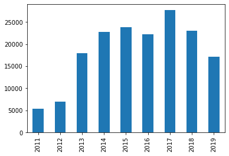

```python
# view data by year
df_raw['year'].value_counts().sort_index().plot(kind='bar', figsize=(6, 4));
```

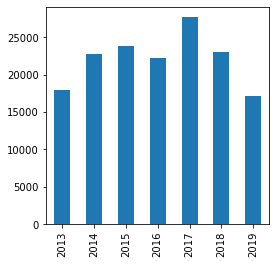

```python
# select 2013-2019
df_raw = df_raw.loc[(df_raw['year']>2012), :].copy()
df_raw['year'].value_counts().sort_index().plot(kind='bar', figsize=(4, 4));
```

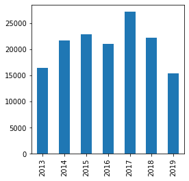

```python
# select trust-years with over 10k words
df_raw['wordcount'] = df_raw['story'].str.split().str.len()
df_raw['trustYear_wordcount'] = df_raw.groupby(['trust_id', 'year'])['wordcount'].transform('sum')
df_raw = df_raw.loc[df_raw['trustYear_wordcount']>10000, :].copy()

# view
df_raw['year'].value_counts().sort_index().plot(kind='bar', figsize=(4, 4));
```

```python
# remove data with missing values
df_raw.shape
df_raw.dropna(inplace=True)
df_raw.shape
```

```
(146685, 14)
```

```
(146685, 14)
```

```python
# number of stories
len(df_raw)
```

```
146685
```

```python
# number of trusts
len(set(df_raw['trust_id']))
```

```
134
```

## Create trust case-mix severity

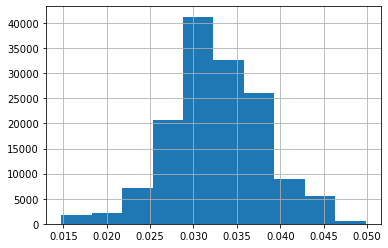

```python
df_raw['trust_caseSeverity'] = df_raw['trust_expectedMortality']/df_raw['trust_spells']

df_raw['trust_caseSeverity'].hist()
```

## Create trust-level data

```python
df = df_raw.groupby(['year', 'trust_id', 'trust_region']).agg(
    trust_spells = ('trust_spells', 'mean'),
    trust_shmi = ('trust_shmi', 'mean'),
    trust_caseSeverity = ('trust_caseSeverity', 'mean'),
    si_all_n = ('si_all_n', 'mean'),
    si_all_rate = ('si_all_rate', 'mean'),
    si_severe_n = ('si_severe_n', 'mean'),
    si_severe_rate = ('si_severe_rate', 'mean'),
    stories_n = ('year', 'size'),
    stories =('story', (lambda x: ' '.join(x))))

df.reset_index(inplace=True)
df.info()
```

```
<class 'pandas.core.frame.DataFrame'>
RangeIndex: 792 entries, 0 to 791
Data columns (total 12 columns):
 #   Column              Non-Null Count  Dtype
---  ------              --------------  -----
 0   year                792 non-null    int64
 1   trust_id            792 non-null    object
 2   trust_region        792 non-null    object
 3   trust_spells        792 non-null    int32
 4   trust_shmi          792 non-null    float64
 5   trust_caseSeverity  792 non-null    float64
 6   si_all_n            792 non-null    int32
 7   si_all_rate         792 non-null    float64
 8   si_severe_n         792 non-null    int32
 9   si_severe_rate      792 non-null    float64
 10  stories_n           792 non-null    int64
 11  stories             792 non-null    object
dtypes: float64(4), int32(3), int64(2), object(3)
memory usage: 65.1+ KB
```

# Natural language processing

```python
# create spacy docs
df['stories_doc'] = df['stories'].progress_apply(nlp)
```

```
HBox(children=(FloatProgress(value=0.0, max=792.0), HTML(value='')))
```

```python
df['wordcount'] = df['stories_doc'].apply(len)
```

## Measuring Sentiment

To measure the sentiment of the patient reviews we use the [VADER](https://github.com/cjhutto/vaderSentiment) (Valence Aware Dictionary and sEntiment Reasoner) algorithm for Python [(Hutto & Gilbert, 2014)](https://www.aaai.org/ocs/index.php/ICWSM/ICWSM14/paper/download/8109/8122). It is a widely used lexicon and rule-based tool designed to measure sentiment in social media. VADER takes account of common negations (e.g., 'not good'), intensity (e.g., 'very', '!!!!', ALL CAPS), slang (e.g., 'sux', 'lol') and emojis. VADER scores each word in context and then produces a composite score ranging from -1 (most negative) to +1 (most positive).

The following cell illustrates how VADER scores six test sentences.

```python
from vaderSentiment.vaderSentiment import SentimentIntensityAnalyzer
analyzer = SentimentIntensityAnalyzer()

test_sentences = ["Superb excellent ++",
                  'easy car park',
                  'he was not happy',
                  'she was dying',
                  'he died very happy',
                  'he died']

for sentence in test_sentences:
    score = analyzer.polarity_scores(sentence)
    print("Sentiment score: {:<6}  '{:}'".format(str(round(score['compound'],2)), sentence))
```

```
Sentiment score: 0.83    'Superb excellent ++'
Sentiment score: 0.44    'easy car park'
Sentiment score: -0.46   'he was not happy'
Sentiment score: 0.0     'she was dying'
Sentiment score: 0.1     'he died very happy'
Sentiment score: -0.56   'he died'
```

```python
# create sentiment extension
def get_sentiment(doc):
    # can return pos, neg, neutral, and overall/compound
    return sentiment_analyzer.polarity_scores(doc.text)['compound']

# create custom extension
Doc.set_extension('sentiment', getter=get_sentiment, force=True)

# function to get sentiment
def getDocSentiment(doc):
    '''
    Uses VADER to get normalized weighted composite score for each sentence
    Output: composite sentiment float (-1 to 1)
    '''
    sentence_sentiments = []
    for sent in doc.sents:
        sentiment = round(sentiment_analyzer.polarity_scores(sent.text)['compound'], 3)
        sentence_sentiments.append(sentiment)
    try:
        doc_sentiment_sentence_mean = round(sum(sentence_sentiments)/len(sentence_sentiments), 3)
    except:
        doc_sentiment_sentence_mean = None

    return doc_sentiment_sentence_mean
```

```python
# apply the VADER sentiment algorithm to the year-trust aggregated patient feedback
df['stories_sentiment'] = df.progress_apply(lambda x: getDocSentiment(x['stories_doc']), axis=1)
```

```
HBox(children=(FloatProgress(value=0.0, max=792.0), HTML(value='')))
```

## Measuring Patient-Reported Safety Incidents

Supervised learning is a more recent approach that models statistical patterns in manually coded data to create a classification algorithm. This approach has the benefit of replicating human coding. However, these models often lack transparency (i.e., it can be difficult to discern why certain text was or was not classified) and the quality of these models is limited by the quality of the input data (e.g. if the human judgements are unreliable, as is the case with staff-reported safety incidents, then the supervised classifier will be unreliable)

Accordingly, we chose to measure patient-reported safety incidents following the Distributed Dictionary Representation (DDR) methodology described by [Garten et al. (2018)](https://doi.org/10.3758/s13428-017-0875-9). This method has the benefit of not being skewed by low-relevance but high-frequnecy terms (like word frequency methods), it is tolerant of the spelling mistakes that are common online (unlike word frequency methods), and it produces normally distributed scores (unlike word frequency methods and supervised learning methods that categorise text).

The DDR methodology requires a distributed language model, where each word within the language model is represented by a vector, or word embedding, so that the similarity of a text to a target concept can be measured. We use the [large spaCy english language model 2.3.1](https://github.com/explosion/spacy-models/releases//tag/en_core_web_lg-2.3.1). This language model has 684,831 unique vectors (i.e. tokens or words) represented in 300 dimensions. Each word in the language model is represented by a vector of 300 numbers. The relationship between any two words, or vectors, in the language model is encoded numerically in the relation between their respective vectors.

The following cell illustrates how the DDR methodology works. The target concept is the single target term 'died'. Using the same sentences as used to illustrate the measurement of sentiment, we then score the similarity of each sentence to the target target term. A score of '1' indicates maximum similarity.

```python
target_term = 'died'

# compare target_term to each test sentence
for sentence in test_sentences:
    score = np.round(nlp(sentence).similarity(nlp(target_term)), 2)
    print("Similarity to 'died':  {:<6}  '{:}'".format(str(score), sentence))
```

```
Similarity to 'died':  0.04    'Superb excellent ++'
Similarity to 'died':  0.23    'easy car park'
Similarity to 'died':  0.52    'he was not happy'
Similarity to 'died':  0.68    'she was dying'
Similarity to 'died':  0.72    'he died very happy'
Similarity to 'died':  0.9     'he died'
```

### Step 1: Start with candidate target-terms

```python
# the candidate terms based on the literature
initial_targetTerms = '''
died fatal harmed misdiagnosed overmedicated paralysed perished readmitted scarred tragic
'''
```

### Step 2: Increase candidate target terms

```python
# function to generate target terms
def getTokensNearVector(nlp, string_terms, limit=300):
    '''
    Takes a string of words and uses the language model to suggest similar words
    '''
    doc = nlp(string_terms)

    vectors = []
    for tok in [tok for tok in doc if tok.is_alpha]:
        try:
            vectors.append(tok.vector)
        except:
            print('error getting vector for ', tok.text)

    #sum vectors
    vector_sum=0
    for v in vectors:
        vector_sum=vector_sum+v
    #get mean vector
    vector=vector_sum/len(vectors)

    # format the input vector for use in the distance function
    p = [np.array(vector)]
    # format the vocabulary for use in the distance function
    ids = [x for x in nlp.vocab.vectors.keys()]
    vectors1 = [nlp.vocab.vectors[x] for x in ids]
    vectors2 = np.array(vectors1)

    # measure distances
    dist = distance.cdist(p,vectors2)[0]

    # create df of results
    df = pd.DataFrame({'distance':[x for x in dist]})
    df.sort_values('distance', inplace=True)

    # collect results
    words = []
    for i in df.index[:limit]:
        word_id = ids[i]
        output_word = nlp.vocab[word_id].text
        output_word = output_word.lower()
        if output_word not in words:
            words.append(output_word.lower())

    # remove input tokens
    words = [word for word in words if word not in [tok.lower_ for tok in doc]]

    # output
    return words
```

```python
# use the distributed language model to get words similar to the initial target terms
related_targetTerms_v1 = []
for term in initial_targetTerms.split():
    term_list = getTokensNearVector(nlp, term, limit=100)
    related_targetTerms_v1 = related_targetTerms_v1+[x for x in term_list if x not in related_targetTerms_v1]
related_targetTerms_v1 = ' '.join(sorted(set(related_targetTerms_v1+initial_targetTerms.split())))
related_targetTerms_v1
```

```
'absconded accident accidental accidents admited admitted adversely affected afflicted after aftermath ailment ailments alive amnd amputated annihilated ansd apparantly apparent apparenty apparrently appearantly appearently appendicitis atrophied awakend badly battered became becaome bed-ridden bedr…
```

```python
# selected terms that may be indicative of a severe safety incident
expanded_targetTerms_v1 = '''
adversely dead deadly death deaths deceased died dies disfigured dying fatal fatality harmed
harming injure killed lethal maimed misdiagnose misdiagnosed misdiagnoses misdiagnosis murdered
mutilating overmedicated paralysed perish perished perishing readmission readmit readmitted scarred
severe succumbed tragic undiagnosed
'''
```

```python
# generate further target term candidates using the expanded list
related_targetTerms_v2 = []
for term in expanded_targetTerms_v1.split():
    term_list = getTokensNearVector(nlp, term, limit=100)
    related_targetTerms_v2 = related_targetTerms_v2+[x for x in term_list if x not in related_targetTerms_v2]
related_targetTerms_v2 = ' '.join(sorted(set(related_targetTerms_v2+related_targetTerms_v1.split())))
related_targetTerms_v2
```

```
'30-day abducted abducting abnd abnormality absconded accident accidental accidents accursed accused acute admissions admited admittance admitted adverse adversely aerosolize affect affected affecting affects afflicted afforementioned afix afraid after aftermath aggravate ailment ailments alive alle…
```

```python
# the expanded list of candidate target terms
expanded_targetTerms_v2 = '''
brutally complication complications dangerous dead deadly death deceased demise departed
destroyed died dieing disfigured doomed dooming dying exacerbation fatal grave grievously
harmed harming homicide kill killed killing maim maimed malpractice miscalculate misdiagnose
misdiagnosed misdiagnosing misdiagnosis misidentified misidentifying misinterpreted
misjudged mistreated mortality mortally murdered murdering murderous mutilate mutilated
overmedicated overmedicating perished readmit readmitted rehospitalization scarred severe
succumb succumbed succumbing suffered suffering tragic tragically traumatised traumatize
traumatized untreated worsen wrongly
'''
```

### Step 3: Assessing the validity high-scoring text

High scoring sentences for each candidate target term are examined. The aim is to select target terms that consistently capture the most severe safety incidents.

```python
# function to get high-scoring sentences
def getSimilarSentencesForEachToken(nlp, docs, target_terms, n_sentences=10,
                                    min_sentence_length=6):
    '''
    Finds most similar sentences for each tonken and all tokens together
    '''

    target_terms = nlp(target_terms.strip())

    # get highest scoring sentences
    for tok in target_terms:
        sentences = []
        similarities = []
        if tok.has_vector:
            #print('TOKEN = ', tok.text)
            for doc in docs:
                for sent in doc.sents:
                    if sent.has_vector:
                        if len(sent)>min_sentence_length:
                            sentences.append(sent.text)
                            similarities.append(tok.similarity(sent))

        df_temp=pd.DataFrame({tok.text: similarities,
                              'sentence': sentences}).round(3).copy()
        #print
        with pd.option_context('display.max_colwidth', 0):
            display(df_temp.sort_values(tok.text, ascending=False).head(n_sentences)
                    .style.set_properties(**{'text-align': 'left'}).hide_index())
```

```python
# display highest scoring sentences, with the sentence score
# reduce sample size to speed up
getSimilarSentencesForEachToken(nlp, df['stories_doc'].sample(600), expanded_targetTerms_v2)
```

| brutally | sentence |
| --- | --- |
| 0.504000 | Their attitude and brutality left him traumatised! |
| 0.495000 | She was disgusted at being forcibly pushed. |
| 0.489000 | They procedure was brutal, extremely painful. |
| 0.487000 | I left very angry and humiliated. |
| 0.485000 | She was rough, unsympathetic and unkind. |
| 0.481000 | The nurse was unkind, rude and unnecessarily rough. |
| 0.480000 | Her face was very badly bruised and swollen and she also banged her head. |
| 0.480000 | Left feeling a bit humiliated and badly treated. |
| 0.477000 | Their manner was brutish, uncaring. |
| 0.477000 | I felt utterly humiliated and refused to undergo the examination. |

| complication | sentence |
| --- | --- |
| 0.623000 | Thankfully the conclusion was gastro enteritis and not a surgical complication. |
| 0.607000 | I have Malignant obstructive jaundice and inoperable cholangiocarcinoma with peritoneal metastases. |
| 0.607000 | Sepsis, Peritonitis and Neuro endocrine tumour. |
| 0.606000 | I have ischaemic heart disease and severe aortic stenosis. |
| 0.604000 | He was diagnosed with DVT, Pulmonary Embolism, Atrial Fibrillation and Acute Acidosis on 29/01/2016 at QEQM Emergency department. |
| 0.600000 | A kidney infection left untreated could cause so many complications. |
| 0.597000 | Same issue of acute renal failure due to ileostomy operation. |
| 0.596000 | The following surgery disclosed a complex appendicitis with peritonitis. |
| 0.591000 | Post operatively she developed faecal peritonitis, small bowel ischaemia, infarction which required further treatment. |
| 0.589000 | After being diagnosed with Kidney Cancer and Pulmonary Embolism. |

| complications | sentence |
| --- | --- |
| 0.728000 | from complications involving terminal pancreatic cancer. |
| 0.709000 | Cancer with complications had been diagnosed. |
| 0.707000 | A kidney infection left untreated could cause so many complications. |
| 0.704000 | After being diagnosed with Kidney Cancer and Pulmonary Embolism. |
| 0.696000 | Cancer patient suffering from severe abdominal pain and vomiting. |
| 0.694000 | a. Educating patients about complications that may arise. |
| 0.690000 | After complications from a benign prostate, I had renal failure. |
| 0.683000 | I have ischaemic heart disease and severe aortic stenosis. |
| 0.677000 | kidney cancer diagnosed 2005 resulting in surgery to remove kidney. |
| 0.677000 | Id suffered with obstetric cholestasis, gestational diabetes and cmv virus so was high risk. |

| dangerous | sentence |
| --- | --- |
| 0.742000 | This is very dangerous and risky. |
| 0.721000 | Very disappointing and potentially very dangerous. |
| 0.679000 | This cavalier attitude is iniquitous, and very dangerous. |
| 0.677000 | This is a very unfair and dangerous situation. |
| 0.675000 | The wait was potentially dangerous without proper triage. |
| 0.671000 | Particularly dangerous as he has heart failure. |
| 0.662000 | This was a very dangerous situation. |
| 0.661000 | Absolutely disgusting & dangerous way to treat a patient. |
| 0.653000 | Leaving very sick patients alone in a corridor is simply dangerous & wholly unacceptable. |
| 0.653000 | Dangerous practice to say the least. |

| dead | sentence |
| --- | --- |
| 0.684000 | I was almost dead and they revived me. |
| 0.682000 | 12 hours later my father was dead. |
| 0.676000 | Bereft of ideas but maybe I was brain dead waiting! |
| 0.669000 | With a dead baby inside me. |
| 0.668000 | The Dr coldly said " He Dead, He`s Dead + proceeded to put an apron + gloves on. |
| 0.660000 | It was like he was dead already and not human. |
| 0.659000 | 4 days of upset and grief knowing i was carrying a dead baby. |
| 0.657000 | Without it I would be dead. |
| 0.656000 | My son substained horrific injuries Weds evening from an attack and been run over and left for dead. |
| 0.651000 | Unfortunately my grandmother suffered a heart attack while at burnley hospital and died. |

| deadly | sentence |
| --- | --- |
| 0.590000 | Passive smoking is lethal – more lethal than first hand smoking. |
| 0.559000 | The Hospital is putting seriously ill patients at further risk of a deadly disease. |
| 0.550000 | Had a near fatal heart attack in June 2016. |
| 0.547000 | Avoid this hospital like the plague! |
| 0.546000 | I suspect the chaos this cyber attack caused must have been horrendous for staff trying to firefight issues. |
| 0.544000 | Apparently it was a severe Asthma attack. |
| 0.543000 | Admitted to acute medical ward, with suspected heart attack. |
| 0.541000 | The mere possibility of cancer is terrifying. |
| 0.540000 | Regrettably, he was one of the victims of the flu mutation thus making his flu vaccination ineffective. |
| 0.540000 | I arrived at A&E at 12.30pm with bad chest pains and a survival card for the deadly dangerous drug I take. |

| death | sentence |
| --- | --- |
| 0.766000 | And the patient died a peaceful death. |
| 0.725000 | My mother in law died after a brain haemorrhage recently. |
| 0.718000 | A formal investigation recently acknowledged that my mother had died of sepsis, almost three years after her death. |
| 0.717000 | It was a most traumatic death. |
| 0.716000 | My mother was taken into Broomfield suffering from pneumonia and a cardiac arrest. |
| 0.713000 | My mother died in the hospital following a bout of pneumonia. |
| 0.710000 | Unfortunately my grandmother suffered a heart attack while at burnley hospital and died. |
| 0.709000 | My brother and father died in a hospice. |
| 0.705000 | Sepsis (ongoing septicaemia/blood poisoning) was listed on her death certificate. |
| 0.700000 | My mother Florence Joan Ingle sadly died after 10 days in hospital having suffered a stroke. |

| deceased | sentence |
| --- | --- |
| 0.561000 | Also my beloved (now deceased) elderly Mother was treated their like a Queen. |
| 0.557000 | Sue (eldest daughter) On behalf of Eileen Powell's Family. |
| 0.552000 | The deceased was not afforded the dignity required. |
| 0.549000 | My brother and father died in a hospice. |
| 0.537000 | My wife died on Will Adams ward. |
| 0.537000 | My father died peacefully surrounded by his loved ones. |
| 0.534000 | My elderly mother was transferred from Hillingdon Hospital to Trinity Ward. |
| 0.534000 | My elderly father was discharged to nursing home. |
| 0.531000 | ~01:00 My father and mother were taken home by their granddaughter. |
| 0.529000 | my elderly mother had vital procedures withheld. |

| demise | sentence |
| --- | --- |
| 0.516000 | Fortunately this whole debacle was witnessed. |
| 0.510000 | My late mother suffered a similar fate at DGH. |
| 0.495000 | You have caused utter despair, utter fear utter suicidal feelings. |
| 0.483000 | Entirely predictable issues were not addressed until discharge was imminent, with inevitable significant delays. |
| 0.477000 | The saddest fact is that what happened was entirely predictable and preventable. |
| 0.476000 | Shortly after admission it became apparent that there had been a death on the ward before our arrival. |
| 0.475000 | A tragic, upsetting situation made much worse by dreadful communication. |
| 0.471000 | Unfortunately her condition deteriorated, necessitating her return back to Lincoln Hospital, resulting in her demise. |
| 0.466000 | Unfortunately she had suffered irreparable heart damage which then led to total heart failure. |
| 0.466000 | My Mother's inquest was heard in August 2015 – the Coroner delivered a narrative verdict' – ‘The deceased suffered from rectal adenocarcinoma. |

| departed | sentence |
| --- | --- |
| 0.508000 | Shortly after the arrival our daughter she was rushed down nicu. |
| 0.506000 | Ambulance arrived promptly, crew excellent. |
| 0.504000 | After my father died we returned to the ward to collect his belongings. |
| 0.504000 | They stayed with my mother until the ambulance arrived. |
| 0.502000 | early Sunday morning rung 111 who reacted promptly sent an ambulance blue star arrived. |
| 0.500000 | My father died peacefully surrounded by his loved ones. |
| 0.499000 | From arriving in a&e we were swiftly moved to resus . |
| 0.498000 | My grandson was discharged fro South Crofty ward this morning. |
| 0.496000 | Eventually my dearest mother passed away. |
| 0.494000 | We stayed the night after our son was born. |

|  | sentence |
| --- | --- |

| destroyed | sentence |
| --- | --- |
| 0.635000 | Completely destroyed, mentally and physically. |
| 0.582000 | They could have completly destroyed my sporting career! |
| 0.577000 | All that trust and respect has been destroyed. |
| 0.576000 | They had lost them plus the drops had been thrown in a cupboard so had to be destroyed. |
| 0.576000 | but has been damaged by security. |
| 0.573000 | Without it many lives would be lost or damaged. |
| 0.569000 | We are devastated...truly devastated. |
| 0.569000 | They have restored my faith in mankind. |
| 0.568000 | The X-ray they said showed as they suspected nothing was damaged broken or fractured it was just muscle damage. |
| 0.567000 | The floors were stained and damaged despite the refurb being only 7 years old. |

| died | sentence |
| --- | --- |
| 0.733000 | My mother recently died in Hillingdon hospital aged 99 years. |
| 0.725000 | My mother was gravely ill and has since died. |
| 0.722000 | Sadly she died after 2 weeks. |
| 0.707000 | My father died a week later. |
| 0.704000 | My brother and father died in a hospice. |
| 0.703000 | My Mother died there in 2010. |
| 0.701000 | My mother died several hours later. |
| 0.700000 | My grandson was born prematurely at 23 weeks. |
| 0.698000 | During the night my mother died from Pneumonia. |
| 0.697000 | He died in agony that afternoon. |

| dieing | sentence |
| --- | --- |
| 0.469000 | next day death rattle writhing in agony twitching moaning. |
| 0.440000 | I believe I was starved unnecessarily. |
| 0.438000 | I feel like I'm dying. |
| 0.428000 | I was beging for c -section!!My hubby was terrified cos I or the baby will die! |
| 0.425000 | And I kept apologising for crying. |
| 0.422000 | My nan died in pain, starved and thirsty. |
| 0.422000 | I then started being violently sick. |
| 0.421000 | I suffered so badly from whooping cough whilst I was pregnant. |
| 0.418000 | I was discharged feeling desperately frightened. |
| 0.417000 | I'm suicidal and harming myself. |

| disfigured | sentence |
| --- | --- |
| 0.441000 | He has severe swelling and a badly disfigured looking shoulder. |
| 0.425000 | Disgusting an left emotionally an physically scarred for life. |
| 0.419000 | Traumatised deeply traumatised by my father's treatment. |
| 0.377000 | Very badly bruised and sprained wrist. |
| 0.375000 | Pressure sores, unkempt, unrecognisable. |
| 0.369000 | when her leg becomes gangrenous or she gets pneumonia? |
| 0.364000 | My husband has been severely impaired and traumatised by this sudden deafness. |
| 0.360000 | My husband Alex suffered a badly bruised or possibly broken knee. ( |
| 0.357000 | The MRSA caused a keloid scar on her chest. |
| 0.356000 | with an extremely painful dislocated jaw. |

| doomed | sentence |
| --- | --- |
| 0.558000 | I now endured yet more hopeless inefficiency. |
| 0.553000 | You have caused utter despair, utter fear utter suicidal feelings. |
| 0.546000 | I was powerless to resist – outnumbered and crippled by terror. |
| 0.538000 | We are left feeling desperate, helpless and hopeless. |
| 0.536000 | Struggling to recount this after another messed up, seemingly incompetent attempted canula insertion. |
| 0.525000 | In general: Badly run Badly staffed Badly built Badly maintained An Orwellian nightmare made reality. |
| 0.524000 | Utterly Heartless NO thought for our feelings. |
| 0.518000 | The ward seemed so disorganized beyond belief. |
| 0.516000 | A tragic, upsetting situation made much worse by dreadful communication. |
| 0.510000 | Quite honestly the whole saga was a shambles and degrading. |

| dooming | sentence |
| --- | --- |
| 0.203000 | You have caused utter despair, utter fear utter suicidal feelings. |
| 0.176000 | Either the ESH is grossly underfunded and/or its budget is mismanaged. |
| 0.171000 | they literally kept mev from divingv into the depths vof depression. |
| 0.168000 | Scraping my previous baby seemed unimaginably cruel. |
| 0.162000 | transferd ftomb rgh trust after heart attack and angiogram . |
| 0.161000 | Worst and most dehumanising outpatients experience ever. |
| 0.160000 | Disgusting attitude belittling people who are unwell. |
| 0.159000 | I now feel cumulatively completely disempowered and dehumanised by my treatment. |
| 0.158000 | I now endured yet more hopeless inefficiency. |
| 0.156000 | This worries me how many people are you x-raying needlessly wasting NHS resources and irradiating patients needlessly. |

| dying | sentence |
| --- | --- |
| 0.699000 | Therefore resulting in my baby dying. |
| 0.695000 | My 83 year old mother was dying without dignity in this hospital. |
| 0.693000 | My nan died in pain, starved and thirsty. |
| 0.685000 | Unfortunately my grandmother suffered a heart attack while at burnley hospital and died. |
| 0.681000 | My elderly father was admitted by ambulance suffering from unexplained bleeding. |
| 0.680000 | I endured a night of terrible sickness feeling like I was dying. |
| 0.680000 | Sadly, he died from a dreadful infection. |
| 0.680000 | My mother was gravely ill and has since died. |
| 0.678000 | This greatly distressed me and my dying sibling. |
| 0.677000 | I was prevented from dying that day. |

| exacerbation | sentence |
| --- | --- |
| 0.502000 | Suffering from Chronic Autoimmune Hepatitis with PSC. |
| 0.500000 | Sepsis, Peritonitis and Neuro endocrine tumour. |
| 0.499000 | I receive treatment for mycobacterium avium infection, polymyositis/squamous cell carcinoma, atrial fibrillation and pulmonary fibrosis. |
| 0.494000 | I have Malignant obstructive jaundice and inoperable cholangiocarcinoma with peritoneal metastases. |
| 0.490000 | He was diagnosed with DVT, Pulmonary Embolism, Atrial Fibrillation and Acute Acidosis on 29/01/2016 at QEQM Emergency department. |
| 0.477000 | I have ischaemic heart disease and severe aortic stenosis. |
| 0.470000 | He had chronic diarrhoea and sepsis. |
| 0.464000 | My husband has Hypertrophic Obstructive Cardiomyopathy. |
| 0.459000 | Often breathlessness is caused by the atrial fibrillation. |
| 0.457000 | Systemic Lupus, and Hashimoto's Thyroiditis. |

| fatal | sentence |
| --- | --- |
| 0.629000 | Misdiagnosis and assumption of husbands injuries after serious accident. |
| 0.595000 | Had a near fatal heart attack in June 2016. |
| 0.594000 | Can be fatal in worst case scenario. |
| 0.589000 | However, a severe and possibly fatal reaction remains a possibility. |
| 0.585000 | Yesterday my husband was involved in a near fatal crash. |
| 0.580000 | I was admitted to this hospital with a near fatal kidney disorder. |
| 0.569000 | I attended minor injuries following a serious dog attack incident on 26/218. |
| 0.569000 | But I could have developed fatal complications. |
| 0.567000 | The infection caused sepsis which caused severe shivering 24 hrs after the biopsy. |
| 0.565000 | Admitted via ambulance after paramedic for suspected heart attack. |

| grave | sentence |
| --- | --- |
| 0.605000 | This would be a grave mistake. |
| 0.583000 | Aneurin Bevan will be spinning in his grave! |
| 0.558000 | And the patient died a peaceful death. |
| 0.554000 | Shame on PALS you do a grave disservice to GUY's reputation . |
| 0.552000 | They felt no stone unturned regarding her sickness. |
| 0.547000 | My poor mother is still lying in hospital mortuary. |
| 0.543000 | My father died peacefully surrounded by his loved ones. |
| 0.542000 | Visited endocrinology with regards to my Graves disease . |
| 0.541000 | I had no idea that I was in grave danger. |
| 0.541000 | My late mother suffered a similar fate at DGH. |

| grievously | sentence |
| --- | --- |
| 0.321000 | Very badly bruised and sprained wrist. |
| 0.318000 | Traumatised deeply traumatised by my father's treatment. |
| 0.318000 | He feels Tameside Hospital is unjustly criticised. |
| 0.309000 | emotionally uplifted, and spiritually nourished. |
| 0.288000 | Luis Teixeira My knee had swollen very badly and was acutely painful. |
| 0.286000 | The Fracture Clinic is grossly understaffed. |
| 0.285000 | It was swiftly diagnosed as a severely ruptured Achilles tendon. |
| 0.279000 | My husband has been severely impaired and traumatised by this sudden deafness. |
| 0.276000 | I felt utterly unsupported, terrified and physically vulnerable. |
| 0.276000 | She was acutely unwell and very breathless. |

|  | sentence |
| --- | --- |

| harmed | sentence |
| --- | --- |
| 0.520000 | She was not believed, mistreated and hurt. |
| 0.513000 | They seem woefully inadequate in dealing with vulnerable elderly person. |
| 0.506000 | Spoken to others who endured this ward, all stated same or were frightened to complain due to vulnerable relatives being patients being further mistreated. |
| 0.505000 | They were physically and verbally abused by some patients and relatives but never complained. |
| 0.505000 | I was so badly discriminated against. |
| 0.501000 | Surely this is an unacceptable delay which could adversely damage my eyesight. |
| 0.500000 | I never witnessed any patient being ignored or mistreated in any other way. |
| 0.500000 | I actually felt bullied and unsafe. |
| 0.500000 | Other badly behaved children using these did not help anyones sanity. |
| 0.499000 | I felt unsafe, undermined, dismissed. |

| harming | sentence |
| --- | --- |
| 0.490000 | I'm suicidal and harming myself. |
| 0.455000 | Its damaging his confidence and affecting his schooling. |
| 0.455000 | Truly moving experience without distress or harm. |
| 0.452000 | This worries me how many people are you x-raying needlessly wasting NHS resources and irradiating patients needlessly. |
| 0.443000 | It is causing undue stress and worry. |
| 0.443000 | Disgusting way to treat ailing, vulnerable and frightened patients. |
| 0.441000 | This does not promote cognitive welbeing and stimulate elderly people's minds. |
| 0.438000 | Other badly behaved children using these did not help anyones sanity. |
| 0.436000 | Surely this is an unacceptable delay which could adversely damage my eyesight. |
| 0.434000 | Thankfully my drug intolerance and needle phobia prevented me taking enough to cause damage. |

| homicide | sentence |
| --- | --- |
| 0.460000 | Armed robber fled, police came asap and ambulance. |
| 0.440000 | There were armed police officers present with a trauma victim , as well as police with other patients. |
| 0.434000 | Misdiagnosis and assumption of husbands injuries after serious accident. |
| 0.431000 | Admitted via ambulance after paramedic for suspected heart attack. |
| 0.429000 | Department is clearly understaffed.... car parking charges are daylight robbery. |
| 0.426000 | Enter the POLICE who arrested her. |
| 0.414000 | The Police charged the suspect who has now self sectioned himself. |
| 0.411000 | The rates being charged are extortion. |
| 0.409000 | However the parking charges at this hospital are absolute daylight robbery. |
| 0.409000 | My husband was admitted following a cardiac arrest. |

| kill | sentence |
| --- | --- |
| 0.676000 | A smile doesn't kill anyone. |
| 0.659000 | It frightens me that I will kill myself. |
| 0.647000 | It's like they want you to kill yourself. |
| 0.642000 | She thought people were trying to kill her. |
| 0.635000 | Thy have sent a mentally ill pationt home who said he wants and tries to kill himself by threatening him of being arrested. |
| 0.634000 | This thought scared me and I did not want to kill my beloved pet. |
| 0.628000 | I am so angry, pneumonia can kill me if not treated soon enough! |
| 0.627000 | id not meant to kill myself they opined. |
| 0.627000 | id not meant to kill myself they opined. |
| 0.620000 | I believe these things killed her. |

| killed | sentence |
| --- | --- |
| 0.644000 | Armed robber fled, police came asap and ambulance. |
| 0.615000 | Was admitted to A&E after being attacked. |
| 0.608000 | Admitted via ambulance after paramedic for suspected heart attack. |
| 0.607000 | Apparently I just being lucky that I never crashed or killed someone. |
| 0.606000 | My mother was gravely ill and has since died. |
| 0.605000 | Unfortunately my grandmother suffered a heart attack while at burnley hospital and died. |
| 0.603000 | I almost died in July through suicide. |
| 0.601000 | But what happened next just killed me. |
| 0.601000 | Yesterday my husband was involved in a near fatal crash. |
| 0.601000 | My two friends who were also in the car tragically died. |

| killing | sentence |
| --- | --- |
| 0.602000 | One even accused me of hurting him. |
| 0.596000 | Thy have sent a mentally ill pationt home who said he wants and tries to kill himself by threatening him of being arrested. |
| 0.595000 | My son substained horrific injuries Weds evening from an attack and been run over and left for dead. |
| 0.590000 | I believe these things killed her. |
| 0.589000 | But what happened next just killed me. |
| 0.586000 | My Father in law was admitted with suspected heart attack. |
| 0.581000 | I was powerless to resist – outnumbered and crippled by terror. |
| 0.581000 | However, it was very disturbing being accused and quizzed of abusing our mother! |
| 0.580000 | My Dad committed suicide due to feeling helpless. |
| 0.580000 | She thought people were trying to kill her. |

| maim | sentence |
| --- | --- |
| 0.250000 | Drunken yobs getting prioritisation over seriously ill people. |
| 0.248000 | They can make anyone laugh as they immobilise you. |
| 0.245000 | don't let us starve and die of thirst! |
| 0.241000 | It frightens me that I will kill myself. |
| 0.236000 | Terrible treatment,disrespect,uncaring and blatantly dishonest. |
| 0.232000 | Nhs direct suspected gallstones and nems suspected pancreitis. |
| 0.231000 | You have caused utter despair, utter fear utter suicidal feelings. |
| 0.230000 | Why mislead patients and treat us like cattle? |
| 0.228000 | I'm suicidal and harming myself. |
| 0.225000 | It seems so inhumane and cruel. |

| maimed | sentence |
| --- | --- |
| 0.391000 | Traumatised deeply traumatised by my father's treatment. |
| 0.383000 | Disgusting an left emotionally an physically scarred for life. |
| 0.356000 | Drunken yobs getting prioritisation over seriously ill people. |
| 0.354000 | Their attitude and brutality left him traumatised! |
| 0.350000 | emotionally uplifted, and spiritually nourished. |
| 0.337000 | I never felt institutionalised or dehumanised. |
| 0.335000 | He is elderly frail and terrified. |
| 0.332000 | Very badly bruised and sprained wrist. |
| 0.331000 | My husband has been severely impaired and traumatised by this sudden deafness. |
| 0.331000 | I am severely disabled both mentally and physically. |

| malpractice | sentence |
| --- | --- |
| 0.541000 | Misdiagnosis and assumption of husbands injuries after serious accident. |
| 0.540000 | general rudeness bordering onto medical negligence. |
| 0.540000 | general rudeness bordering onto medical negligence. |
| 0.506000 | A Director of the CQC, and a clinical negligence lawyer. |
| 0.503000 | At best it is carelessness and at worst medical negligence, and I will be making a formal complaint and a medical negligence claim against York Hospital. |
| 0.493000 | Midwives, obstetricians and anesthetist credit to hospital and nhs in general. |
| 0.481000 | to take elderly medical procedure cases. |
| 0.477000 | For the last 3 1/2 years I have worked for a large law firm in Clinical Negligence handling and advising potential new clients and collating medical records for complex medical negligence claims. |
| 0.472000 | Mistreatment of injury resulting in a worse injury after treatment. ' |
| 0.470000 | procedure preformed by Mr Hampton Orthopaedic consultant and a spinal anaesthetic with sedation by Dr Hussein consultant Anaesthetist. |

| miscalculate | sentence |
| --- | --- |
| 0.131000 | How can this misdiagnose take place? |
| 0.126000 | Doreen Davey 9 Lyndhurst View Scholes. |
| 0.122000 | transferd ftomb rgh trust after heart attack and angiogram . |
| 0.122000 | The surgey is always overbooked and understaffed. |
| 0.121000 | Everything I owuld hvae hoped for. |
| 0.115000 | Either the ESH is grossly underfunded and/or its budget is mismanaged. |
| 0.110000 | Did they underestimate my dilatation speed? |
| 0.105000 | No wonder they get demoralised and sometimes appear hassled/inattentive. |
| 0.105000 | I woild definitlet reccommend basildon hospital to anyone. |
| 0.104000 | The Fracture Clinic is grossly understaffed. |

| misdiagnose | sentence |
| --- | --- |
| 0.229000 | These are Endometriosis, Polycystic ovary syndrome and Premenstrual Disphoric Disorder. |
| 0.225000 | Nhs direct suspected gallstones and nems suspected pancreitis. |
| 0.208000 | How can this misdiagnose take place? |
| 0.195000 | Had xrays and MRI arthsogram to diagnose. |
| 0.190000 | Sepsis, Peritonitis and Neuro endocrine tumour. |
| 0.175000 | I have recurrent cholesteatoma and hyperacusis. |
| 0.175000 | I have a incurable disease called Myasthenia Gravis. |
| 0.174000 | I have Malignant obstructive jaundice and inoperable cholangiocarcinoma with peritoneal metastases. |
| 0.172000 | I had a hysterectomy and bilateral salpingo oopherectomy for premenstrual dysphoric disorder PMDD. |
| 0.170000 | Systemic Lupus, and Hashimoto's Thyroiditis. |

|  | sentence |
| --- | --- |

| misdiagnosed | sentence |
| --- | --- |
| 0.496000 | Had suspected appendicitis with associated symptoms. |
| 0.486000 | They diagnosed me with bacterial tonsillitis. |
| 0.484000 | He was diagnosed antenatally with spina bifida. |
| 0.483000 | These are Endometriosis, Polycystic ovary syndrome and Premenstrual Disphoric Disorder. |
| 0.464000 | After being diagnosed with Kidney Cancer and Pulmonary Embolism. |
| 0.462000 | Private doctor diagnosed pneumonia and prescribed antibiotics. |
| 0.457000 | Cancer with complications had been diagnosed. |
| 0.457000 | A benign cyst was diagnosed and aspirated. |
| 0.455000 | All of these doctors missed all my diagnoses of Ehlers Danlos syndrome, inflammatory arthritis and psoriasis, bilateral bursitis and piriformis syndrome and PoTS. |
| 0.454000 | I have Malignant obstructive jaundice and inoperable cholangiocarcinoma with peritoneal metastases. |

| misdiagnosing | sentence |
| --- | --- |
| 0.198000 | Nhs direct suspected gallstones and nems suspected pancreitis. |
| 0.155000 | Sepsis, Peritonitis and Neuro endocrine tumour. |
| 0.146000 | helier gynaecologist department for a colposcopy. |
| 0.131000 | I had a hysterectomy and bilateral salpingo oopherectomy for premenstrual dysphoric disorder PMDD. |
| 0.130000 | These are Endometriosis, Polycystic ovary syndrome and Premenstrual Disphoric Disorder. |
| 0.125000 | Systemic Lupus, and Hashimoto's Thyroiditis. |
| 0.117000 | I have Malignant obstructive jaundice and inoperable cholangiocarcinoma with peritoneal metastases. |
| 0.116000 | I have recurrent cholesteatoma and hyperacusis. |
| 0.110000 | transferd ftomb rgh trust after heart attack and angiogram . |
| 0.109000 | Visited CCU dept in Epsom Hospotal for breathlessness. |

| misdiagnosis | sentence |
| --- | --- |
| 0.429000 | Misdiagnosis and assumption of husbands injuries after serious accident. |
| 0.395000 | Miscommunication regarding actual diagnosis poor and factually incorrect. |
| 0.394000 | The misdiagnosis, and opportunities to subsequently correct this misdiagnosis constitute unacceptably poor quality care. |
| 0.378000 | Sepsis, Peritonitis and Neuro endocrine tumour. |
| 0.374000 | These are Endometriosis, Polycystic ovary syndrome and Premenstrual Disphoric Disorder. |
| 0.371000 | Suffering from Chronic Autoimmune Hepatitis with PSC. |
| 0.370000 | from complications involving terminal pancreatic cancer. |
| 0.365000 | Nhs direct suspected gallstones and nems suspected pancreitis. |
| 0.362000 | After being diagnosed with Kidney Cancer and Pulmonary Embolism. |
| 0.361000 | All of these doctors missed all my diagnoses of Ehlers Danlos syndrome, inflammatory arthritis and psoriasis, bilateral bursitis and piriformis syndrome and PoTS. |

| misidentified | sentence |
| --- | --- |
| 0.241000 | Nhs direct suspected gallstones and nems suspected pancreitis. |
| 0.228000 | Miscommunication regarding actual diagnosis poor and factually incorrect. |
| 0.206000 | Had suspected appendicitis with associated symptoms. |
| 0.199000 | The Fracture Clinic is grossly understaffed. |
| 0.198000 | Suspected appendicitis was diagnosed and I was admitted. |
| 0.196000 | The quantities served were woefully inadequate. |
| 0.196000 | This was a wrongly assumed attribute. |
| 0.196000 | This was a wrongly assumed attribute. |
| 0.190000 | She was referred by Penrith hospital with a suspected appendicitis. |
| 0.184000 | Took second opinion at UCLH Colorectal surgeon who also seemingly misdiagnosed. |

| misidentifying | sentence |
| --- | --- |
| 0.101000 | Nhs direct suspected gallstones and nems suspected pancreitis. |
| 0.077000 | Doreen Davey 9 Lyndhurst View Scholes. |
| 0.070000 | Miscommunication regarding actual diagnosis poor and factually incorrect. |
| 0.046000 | helier gynaecologist department for a colposcopy. |
| 0.026000 | Patricia Symons-from Gravesend Kent. |
| 0.024000 | Sepsis, Peritonitis and Neuro endocrine tumour. |
| 0.023000 | he had entero-enteric or entero-cutameous fistulas. |
| 0.011000 | The diagnosis was a paralytic ileus. |
| 0.003000 | transferd ftomb rgh trust after heart attack and angiogram . |
| 0.001000 | Had suspected appendicitis with associated symptoms. |

| misinterpreted | sentence |
| --- | --- |
| 0.494000 | Miscommunication regarding actual diagnosis poor and factually incorrect. |
| 0.424000 | She was unhelpful, uninformed and unprofessional. |
| 0.423000 | Terrible treatment,disrespect,uncaring and blatantly dishonest. |
| 0.420000 | Was confronted by a dismissive rude midwife. |
| 0.416000 | I felt completely disregarded, belittled and treated in a sexist manner. |
| 0.414000 | Conversely the technician today seemed overtly rude and unhelpful. |
| 0.412000 | To misquote a common Xtian phrase ‘ ‘what would Anerin Bevan say? |
| 0.411000 | Nonetheless, I was mortified by his insensitive and frankly unprofessional comment. |
| 0.405000 | This is grossly irresponsible in my opinion. |
| 0.400000 | Nurse attitudes are unprofessional and dismissive. |

|  | sentence |
| --- | --- |

| misjudged | sentence |
| --- | --- |
| 0.335000 | I feel fobbed off and belittled. |
| 0.326000 | I felt unsafe, undermined, dismissed. |
| 0.321000 | I have never felt so patronised and belittled. |
| 0.310000 | Glib, insensitive advice that underestimated my daughter's intelligence. |
| 0.310000 | She was unhelpful, uninformed and unprofessional. |
| 0.308000 | This left me feeling undervalued, undignified and disappointed. |
| 0.306000 | Terrible treatment,disrespect,uncaring and blatantly dishonest. |
| 0.304000 | Nonetheless, I was mortified by his insensitive and frankly unprofessional comment. |
| 0.299000 | The surgey is always overbooked and understaffed. |
| 0.297000 | The staff are rushed, hugely overworked, yet never disrespectful, unprofessional or uncaring. |

| mistreated | sentence |
| --- | --- |
| 0.455000 | She was not believed, mistreated and hurt. |
| 0.439000 | Traumatised deeply traumatised by my father's treatment. |
| 0.430000 | He feels Tameside Hospital is unjustly criticised. |
| 0.430000 | I was left feeling humiliated, angry and uncared for. |
| 0.429000 | I felt uncared for, ignored, admonished and untreated. |
| 0.428000 | I feel so insulted and uncared for whilst being extremely vulnerable. |
| 0.422000 | I have been lied to, treated very badly,humiliated. |
| 0.419000 | They were physically and verbally abused by some patients and relatives but never complained. |
| 0.418000 | Extremely mismanaged and treated appalling by staff. |
| 0.414000 | I was so badly discriminated against. |

| mortality | sentence |
| --- | --- |
| 0.605000 | Sepsis kills 36?000 - 64?000 annually in UK, with mortality rate of 35%. |
| 0.572000 | I have ischaemic heart disease and severe aortic stenosis. |
| 0.563000 | Olighydramnosis & fetal distress syndrome in previous pregnancies. |
| 0.553000 | Id suffered with obstetric cholestasis, gestational diabetes and cmv virus so was high risk. |
| 0.551000 | He was diagnosed with DVT, Pulmonary Embolism, Atrial Fibrillation and Acute Acidosis on 29/01/2016 at QEQM Emergency department. |
| 0.550000 | High risk pregnancy with risk of placenta abruption. |
| 0.549000 | Diagnosis: Pulmonary emboli both lungs & pneumonia in the lower left lung. |
| 0.549000 | Diagnosis: Pulmonary emboli both lungs & pneumonia in the lower left lung. |
| 0.547000 | His conditions include coronary heart disease, hypertension, high bloodsugar and cholesterol. |
| 0.535000 | I receive treatment for mycobacterium avium infection, polymyositis/squamous cell carcinoma, atrial fibrillation and pulmonary fibrosis. |

| mortally | sentence |
| --- | --- |
| 0.346000 | I was discharged feeling desperately frightened. |
| 0.324000 | Traumatised deeply traumatised by my father's treatment. |
| 0.315000 | She was acutely unwell and very breathless. |
| 0.315000 | My mother was gravely ill and has since died. |
| 0.314000 | He is elderly frail and terrified. |
| 0.313000 | He recovered and was discharged promptly. |
| 0.311000 | My son visited casualty at Newark hospital after badly spraining his ankle. |
| 0.310000 | My elderly father was admitted by ambulance suffering from unexplained bleeding. |
| 0.310000 | He was very frail, confused and disoriented. |
| 0.309000 | Thankfully he recovered quickly and he was discharged. |

| murdered | sentence |
| --- | --- |
| 0.555000 | Armed robber fled, police came asap and ambulance. |
| 0.539000 | Enter the POLICE who arrested her. |
| 0.527000 | My father died peacefully surrounded by his loved ones. |
| 0.525000 | When Dad died, he was surrounded by his wife and children. |
| 0.520000 | My mother was gravely ill and has since died. |
| 0.520000 | Thy have sent a mentally ill pationt home who said he wants and tries to kill himself by threatening him of being arrested. |
| 0.512000 | Was admitted to A&E after being attacked. |
| 0.511000 | My Father in law was admitted with suspected heart attack. |
| 0.510000 | Recently elderly father admitted to Heartlands. |
| 0.508000 | My father was admitted after a suspected stroke. |

| murdering | sentence |
| --- | --- |
| 0.441000 | However, it was very disturbing being accused and quizzed of abusing our mother! |
| 0.439000 | Thy have sent a mentally ill pationt home who said he wants and tries to kill himself by threatening him of being arrested. |
| 0.437000 | My daughter was accused of being a heroin addict by the safeguarding team. |
| 0.428000 | One even accused me of hurting him. |
| 0.427000 | A policeman was dealing with an aggressively drunk woman. |
| 0.427000 | Enter the POLICE who arrested her. |
| 0.427000 | Armed robber fled, police came asap and ambulance. |
| 0.424000 | Secondly, the consultant repeatedly accused me of lying. |
| 0.421000 | The Police charged the suspect who has now self sectioned himself. |
| 0.419000 | My Father in law was admitted with suspected heart attack. |

| murderous | sentence |
| --- | --- |
| 0.525000 | Its vile its disgusting its inhuman. |
| 0.489000 | Their manner was brutish, uncaring. |
| 0.487000 | Selfish, loud and utterly vile. |
| 0.484000 | His manner was brusque and vile. |
| 0.478000 | Their attitude and brutality left him traumatised! |
| 0.469000 | We faced a ruthless evil which had to be overcome. |
| 0.463000 | What I witnessed was uncaring and inhumane. |
| 0.456000 | You have caused utter despair, utter fear utter suicidal feelings. |
| 0.455000 | It seems so inhumane and cruel. |
| 0.452000 | This view is utterly inhumane and frankly sickening. |

| mutilate | sentence |
| --- | --- |
| 0.211000 | They don't do abortion or miscarriage complication aftercare at Basildon. |
| 0.194000 | don't let us starve and die of thirst! |
| 0.192000 | I never felt institutionalised or dehumanised. |
| 0.190000 | To repair perforation, remove infection and infected bones. |
| 0.188000 | It frightens me that I will kill myself. |
| 0.185000 | I felt degraded to be told that my joints don't dislocate. |
| 0.185000 | They can make anyone laugh as they immobilise you. |
| 0.183000 | hurt wrist- swollen painful unable to use. |
| 0.182000 | They then swiftly diagnosed inflamed and infected gall bladder. |
| 0.181000 | I'm suicidal and harming myself. |

| mutilated | sentence |
| --- | --- |
| 0.371000 | Sadly both washrooms were unclean covered in excrement. |
| 0.371000 | Traumatised deeply traumatised by my father's treatment. |
| 0.360000 | Disgusting an left emotionally an physically scarred for life. |
| 0.354000 | My Son was airlifted to A&E with suspected broken pelvis and leg. |
| 0.352000 | Very badly bruised and sprained wrist. |
| 0.352000 | My husband Alex suffered a badly bruised or possibly broken knee. ( |
| 0.352000 | He has severe swelling and a badly disfigured looking shoulder. |
| 0.349000 | My Arms and hands are battered and Bruised. |
| 0.348000 | They were visibly affected by my pitiful and humiliating condition. |
| 0.346000 | No bones broken, grazed arm treated and instructions given. |

|  | sentence |
| --- | --- |

| overmedicated | sentence |
| --- | --- |
| 0.141000 | Systemic Lupus, and Hashimoto's Thyroiditis. |
| 0.136000 | I never felt institutionalised or dehumanised. |
| 0.111000 | Maybe demented patients could be sedated. |
| 0.098000 | Sepsis, Peritonitis and Neuro endocrine tumour. |
| 0.090000 | The surgey is always overbooked and understaffed. |
| 0.089000 | I now feel cumulatively completely disempowered and dehumanised by my treatment. |
| 0.089000 | Today I visted PRH Haywards Heath. |
| 0.086000 | I have an underactive thyroid, overweight & PCOS. |
| 0.084000 | Private doctor diagnosed pneumonia and prescribed antibiotics. |
| 0.080000 | I was sedated with midazolam and fentanyl. |

| overmedicating | sentence |
| --- | --- |
| 0.137000 | Mrs Judith Molyneux H2 Ward. - |
| 0.124000 | Nhs direct suspected gallstones and nems suspected pancreitis. |
| 0.112000 | Whittington doesn't triage for DVT. |
| 0.103000 | Queen Elizabeth in Woolwich/Eltham. |
| 0.101000 | Sepsis, Peritonitis and Neuro endocrine tumour. |
| 0.089000 | Patricia Symons-from Gravesend Kent. |
| 0.085000 | Cardiology outpatients at Blackburn hospital is disgraceful. |
| 0.083000 | Systemic Lupus, and Hashimoto's Thyroiditis. |
| 0.077000 | Visited CCU dept in Epsom Hospotal for breathlessness. |
| 0.076000 | Doreen Davey 9 Lyndhurst View Scholes. |

| perished | sentence |
| --- | --- |
| 0.420000 | Sadly he was unfit for surgery and deteriorated and subsequently died. |
| 0.419000 | My father died peacefully surrounded by his loved ones. |
| 0.411000 | Not long after they were readmitted but baby had died. |
| 0.409000 | Sadly, he died from a dreadful infection. |
| 0.406000 | He died in agony that afternoon. |
| 0.406000 | My two friends who were also in the car tragically died. |
| 0.405000 | The ambulance attendants were kindness personified. |
| 0.405000 | My mother was gravely ill and has since died. |
| 0.404000 | When she died they were so comforting. |
| 0.404000 | He lost 2.4 stone in3 weeks- he was starving. |

| readmit | sentence |
| --- | --- |
| 0.237000 | Discharged to be readmitted 1week later! |
| 0.131000 | Appointment to MSK triaged with Physio. |
| 0.107000 | I had to readmit her, by calling an ambulance. |
| 0.103000 | Admitted straight.to Urology to have Cathetar reinstated. |
| 0.090000 | Nhs direct suspected gallstones and nems suspected pancreitis. |
| 0.089000 | After 15hours of operation staying 3days icu. |
| 0.089000 | I woild definitlet reccommend basildon hospital to anyone. |
| 0.088000 | Admitted to AMU Ward and eventually on to CCU ward. |
| 0.086000 | Doreen Davey 9 Lyndhurst View Scholes. |
| 0.086000 | 3 days later, readmitted with suspected septicemia! |

| readmitted | sentence |
| --- | --- |
| 0.584000 | Discharged to be readmitted 1week later! |
| 0.405000 | 3 days later, readmitted with suspected septicemia! |
| 0.346000 | Had to be readmitted Thursday morning. |
| 0.327000 | Admitted straight.to Urology to have Cathetar reinstated. |
| 0.316000 | I ended up being readmitted twice after. |
| 0.309000 | He was discharged prematurely after a few days and had to be readmitted. |
| 0.305000 | Was admitted to hospital with acute diverticulitis. |
| 0.293000 | I developed a haematoma immediately on discharge and ended up being readmitted. |
| 0.287000 | G.W.Turner I was readmitted into Basildon University Hospital on the 5th March. |
| 0.285000 | My daughter has been an inpatient since Saturday having only been discharged Friday then readmitted. |

| rehospitalization | sentence |
| --- | --- |
| 0.257000 | He was diagnosed with DVT, Pulmonary Embolism, Atrial Fibrillation and Acute Acidosis on 29/01/2016 at QEQM Emergency department. |
| 0.227000 | This patient has atrial fibrillation and therefore cardiac incompetence. |
| 0.225000 | Sepsis, Peritonitis and Neuro endocrine tumour. |
| 0.224000 | Cardiology outpatients at Blackburn hospital is disgraceful. |
| 0.211000 | I receive treatment for mycobacterium avium infection, polymyositis/squamous cell carcinoma, atrial fibrillation and pulmonary fibrosis. |
| 0.211000 | I have ischaemic heart disease and severe aortic stenosis. |
| 0.209000 | Diagnosed with dilated aortic root and consequent aortic valve regurgitation. |
| 0.209000 | Diagnosed with dilated aortic root and consequent aortic valve regurgitation. |
| 0.199000 | Often breathlessness is caused by the atrial fibrillation. |
| 0.186000 | Post operatively she developed faecal peritonitis, small bowel ischaemia, infarction which required further treatment. |

| scarred | sentence |
| --- | --- |
| 0.561000 | Disgusting an left emotionally an physically scarred for life. |
| 0.549000 | Traumatised deeply traumatised by my father's treatment. |
| 0.518000 | Her lungs are permanently scarred and won't fully recover. |
| 0.517000 | My veins get scarred due to it. |
| 0.514000 | He has severe swelling and a badly disfigured looking shoulder. |
| 0.506000 | Very badly bruised and sprained wrist. |
| 0.495000 | My Arms and hands are battered and Bruised. |
| 0.487000 | Luis Teixeira My knee had swollen very badly and was acutely painful. |
| 0.485000 | The MRSA caused a keloid scar on her chest. |
| 0.481000 | emotionally uplifted, and spiritually nourished. |

| severe | sentence |
| --- | --- |
| 0.785000 | Cancer patient suffering from severe abdominal pain and vomiting. |
| 0.781000 | I had an acute severe illness presenting with excruciating abdominal pain. |
| 0.763000 | The infection caused sepsis which caused severe shivering 24 hrs after the biopsy. |
| 0.762000 | Patient's condition worsened - severe jaundice set in. |
| 0.761000 | It involves bouts of excessive vomiting for days with severe epigastric pain. |
| 0.758000 | I m a sufferer of degenerate disc disease and suffer severe disabling neck pain (all cerviacle discs have prolapsed or Bulged causing occipital neuralgia, the pain is unbearable' Severe disabling thor… |
| 0.751000 | Severe debilitating nausea and vomitting at 8 weeks pregnant. |
| 0.749000 | It was a severe bladder and kidney infection and chronic constipation. |
| 0.749000 | My daughter suffers from severe eczema. |
| 0.746000 | I went to the Hospital suffering from chronic gastritis with severe pain. |

|  | sentence |
| --- | --- |

| succumb | sentence |
| --- | --- |
| 0.537000 | You have caused utter despair, utter fear utter suicidal feelings. |
| 0.468000 | I was powerless to resist – outnumbered and crippled by terror. |
| 0.466000 | don't let us starve and die of thirst! |
| 0.462000 | I continue to suffer severe from haemorrhages. |
| 0.456000 | Completely abandoned and left to suffer excruciating pain. |
| 0.451000 | I now endured yet more hopeless inefficiency. |
| 0.450000 | Unable to breath in extreme agony. |
| 0.448000 | I suffer badly from panic attacks. |
| 0.447000 | I admire the previous patients capacity to suffer a debilitating chronic illness. |
| 0.443000 | So cruel to let a person suffer pain. |

| succumbed | sentence |
| --- | --- |
| 0.517000 | Husband was admitted after suffering seizures. |
| 0.510000 | Mum was admitted to A&E with suspected pneumonia and suffering hypothermia. |
| 0.501000 | My grandad was recently admitted after being rushed in, suffering with severe chest pains. |
| 0.499000 | Sadly, he died from a dreadful infection. |
| 0.496000 | Unfortunately my grandmother suffered a heart attack while at burnley hospital and died. |
| 0.494000 | She had suffered a stroke and was left side paralysed. |
| 0.494000 | My 70yr father had pneumonia and temporary paralysis. |
| 0.490000 | She still remained unconscious and prognosis was dire. |
| 0.488000 | My daughter was admitted to ward 12 suffering from severe pneumonia. |
| 0.485000 | My father was admitted recently with severe anaemia. |

| succumbing | sentence |
| --- | --- |
| 0.428000 | You have caused utter despair, utter fear utter suicidal feelings. |
| 0.402000 | He was suffering from severe stomach pains. |
| 0.401000 | He suffers ffrom chronic heart failure and is extremely frail. |
| 0.399000 | I was powerless to resist – outnumbered and crippled by terror. |
| 0.398000 | next day death rattle writhing in agony twitching moaning. |
| 0.398000 | I didn't despite suffering severe brusing. |
| 0.396000 | Mum was admitted to A&E with suspected pneumonia and suffering hypothermia. |
| 0.393000 | she was still suffering from severe spasms. |
| 0.390000 | She helped allay my fears about undergoing general anaesthetic. |
| 0.389000 | Unknowingly I had apparently suffered with angina symptoms for years without realising it. |

| suffered | sentence |
| --- | --- |
| 0.778000 | I unfortunately suffered a head injury and sustained severe concussion. |
| 0.739000 | I have recently suffered a knee injury. |
| 0.720000 | She has been suffering from severe pains. |
| 0.714000 | He was suffering from severe stomach pains. |
| 0.708000 | Husband was admitted after suffering seizures. |
| 0.705000 | she was still suffering from severe spasms. |
| 0.704000 | I sustained a head injury and was diagnosed with severe concussion. |
| 0.700000 | Husband had bad fall with severe facial injuries. |
| 0.698000 | My husband had a severe ankle injury. |
| 0.697000 | Where he was diagnosed as having suffered an angina attack. |

| suffering | sentence |
| --- | --- |
| 0.790000 | She has been suffering from severe pains. |
| 0.787000 | He was suffering from severe stomach pains. |
| 0.782000 | I was suffering from Chronic Pain. |
| 0.768000 | He was suffering with severe back pain. |
| 0.762000 | I went to the Hospital suffering from chronic gastritis with severe pain. |
| 0.762000 | I suffer from severe chronic neuropathic pain which destroys any quality of life. |
| 0.761000 | she was still suffering from severe spasms. |
| 0.759000 | She is very frail and suffering severe back pain. |
| 0.756000 | My father was admitted via A&E suffering from severe stomach pain. |
| 0.755000 | Human beings are left crying out in pain suffering . |

| tragic | sentence |
| --- | --- |
| 0.620000 | A tragic, upsetting situation made much worse by dreadful communication. |
| 0.617000 | Sunderland Royal held specific tragic memories. |
| 0.588000 | The whole situation is heartbreaking and disgusting. |
| 0.579000 | After a terrible accident to be treated this way is utterly shocking. |
| 0.579000 | It was a most traumatic death. |
| 0.578000 | The saddest fact is that what happened was entirely predictable and preventable. |
| 0.576000 | The irony would be beautiful were it not tragic. |
| 0.572000 | A very shocking, frightening and tragic event was made as human and bearable as i could have in my nightmares imagined. |
| 0.567000 | Misdiagnosis and assumption of husbands injuries after serious accident. |
| 0.564000 | Fortunately this whole debacle was witnessed. |

| tragically | sentence |
| --- | --- |
| 0.511000 | My mother was gravely ill and has since died. |
| 0.504000 | Sadly he was unfit for surgery and deteriorated and subsequently died. |
| 0.493000 | Tragically an incredibly brave fellow bowel transplant patient had passed away a few days earlier. |
| 0.491000 | Sadly, he died from a dreadful infection. |
| 0.489000 | a healthy man never hospitalised to dangerously poorly. |
| 0.488000 | Sadly my cousins husband died at Barts recently. |
| 0.486000 | My two friends who were also in the car tragically died. |
| 0.481000 | Unfortunately my grandmother suffered a heart attack while at burnley hospital and died. |
| 0.479000 | Misdiagnosis and assumption of husbands injuries after serious accident. |
| 0.477000 | It was swiftly diagnosed as a severely ruptured Achilles tendon. |

| traumatised | sentence |
| --- | --- |
| 0.570000 | Traumatised deeply traumatised by my father's treatment. |
| 0.418000 | I felt terrified and traumatised by the experience. |
| 0.405000 | Still traumatized and distressed by treatment. |
| 0.391000 | My Mum has been left traumatized. |
| 0.387000 | I never felt institutionalised or dehumanised. |
| 0.373000 | I have been left feeling severely traumatised by this experience. |
| 0.368000 | My husband has been severely impaired and traumatised by this sudden deafness. |
| 0.368000 | I felt utterly unsupported, terrified and physically vulnerable. |
| 0.366000 | Their attitude and brutality left him traumatised! |
| 0.366000 | I now feel cumulatively completely disempowered and dehumanised by my treatment. |

| traumatize | sentence |
| --- | --- |
| 0.225000 | Traumatised deeply traumatised by my father's treatment. |
| 0.217000 | How can a phycologist treat arthritic and nerve damage pain? |
| 0.213000 | I now feel cumulatively completely disempowered and dehumanised by my treatment. |
| 0.210000 | emotionally uplifted, and spiritually nourished. |
| 0.210000 | I never felt institutionalised or dehumanised. |
| 0.201000 | The worry exacerbates to undescribable stress and anxiety. |
| 0.189000 | I woild definitlet reccommend basildon hospital to anyone. |
| 0.185000 | Maybe demented patients could be sedated. |
| 0.182000 | Sepsis, Peritonitis and Neuro endocrine tumour. |
| 0.177000 | I suffer from SOD Sphincter Of Oddie Dysfunction. |

|  | sentence |
| --- | --- |

| traumatized | sentence |
| --- | --- |
| 0.636000 | Traumatised deeply traumatised by my father's treatment. |
| 0.552000 | Still traumatized and distressed by treatment. |
| 0.502000 | I felt terrified and traumatised by the experience. |
| 0.484000 | WE were traumatized by this incident. |
| 0.483000 | My Mum has been left traumatized. |
| 0.478000 | She were crying frightened experiencing severe panic attacks has she has ptsd. |
| 0.477000 | Disgusting an left emotionally an physically scarred for life. |
| 0.473000 | I felt utterly unsupported, terrified and physically vulnerable. |
| 0.470000 | Patients are anxious,elderly and frightened. |
| 0.470000 | My husband has been severely impaired and traumatised by this sudden deafness. |

| untreated | sentence |
| --- | --- |
| 0.583000 | A kidney infection left untreated could cause so many complications. |
| 0.573000 | So my acute eye condition goes untreated. |
| 0.554000 | Untreated this can lead to eptopoc pregnancies and infertility. |
| 0.554000 | Untreated this can lead to eptopoc pregnancies and infertility. |
| 0.546000 | I have Malignant obstructive jaundice and inoperable cholangiocarcinoma with peritoneal metastases. |
| 0.538000 | Suffering from Chronic Autoimmune Hepatitis with PSC. |
| 0.526000 | A Urinary Infection went untreated because I was told the treatment may cause diarrhoea. |
| 0.525000 | Repeated urine infections and since being diagnosed with mbl. |
| 0.523000 | I receive treatment for mycobacterium avium infection, polymyositis/squamous cell carcinoma, atrial fibrillation and pulmonary fibrosis. |
| 0.519000 | I suffer from chronic diverticular disease. |

| worsen | sentence |
| --- | --- |
| 0.559000 | My ill health unsued and symptoms worsened. |
| 0.544000 | This process was very stressful and caused my condition to worsen resulting in vomiting and severe stomach pains. |
| 0.537000 | Patient's condition worsened - severe jaundice set in. |
| 0.521000 | The worry exacerbates to undescribable stress and anxiety. |
| 0.521000 | This caused extreme constipation and developed into overspill diarrhoea. |
| 0.512000 | I continue to suffer severe from haemorrhages. |
| 0.511000 | Cancer patient suffering from severe abdominal pain and vomiting. |
| 0.511000 | Meanwhile, my sight continues to worsen. |
| 0.511000 | It was a severe bladder and kidney infection and chronic constipation. |
| 0.511000 | This condition causes depression and suicidal tendencies. |

| wrongly | sentence |
| --- | --- |
| 0.594000 | This was a wrongly assumed attribute. |
| 0.594000 | This was a wrongly assumed attribute. |
| 0.579000 | He feels Tameside Hospital is unjustly criticised. |
| 0.533000 | I had been wrongly sent to A&E from another department, wrongly according to the receptionist anyway. |
| 0.523000 | The nurses wrongly assumed she had the operation privately and were completely uncaring. |
| 0.522000 | I was so badly discriminated against. |
| 0.519000 | Matron openly lied about actions to be taken. |
| 0.515000 | Hospital staff are often criticized, unfairly I believe and thus deserve this plaudit. |
| 0.514000 | Apparently the appointment ‘outcome' was keyed incorrectly as someone hadn't read the form properly. |
| 0.513000 | The NHS is often maligned, in my opinion unfairly so. |

```python
# these are the terms that are selected (based on the above sentences) to be valid
valid_targetTerms = '''
dangerous dead deadly deceased died dieing disfigured dying error grave harmed incapacitated incompetent
killed killing maimed malpractice misdiagnosed misdiagnosing misidentified misidentifying misinterpreted
misjudged misled mistake mistaken mortally murdered murdering murderous mutilated overmedicated perished
preventable readmission readmitted readmitting scarred succumb succumbed succumbing traumatised wrongly
'''
```

### Step 4: Assessing the reliability of target-terms

Here we apply each candidate target term to the reviews individually, and then examine the correlations between the measures. The aim is to identify target terms that have good inter-term reliability.

```python
def reliabilityOfDDR(nlp, docs, target_terms):
    '''
    Finds the Cronbach alpha for target-terms
    '''

    target_words = nlp(target_terms)

    # score data
    docs_measures = []
    for doc in docs:
        if doc.has_vector:
            doc_measures = {}
            out_of_vocab = []
            doc_measures['doc'] = doc
            for target_token in target_words:
                if target_token.is_oov:
                    pass
                else:
                    doc_measure = target_token.similarity(doc)
                    doc_measures[target_token] = doc_measure
            docs_measures.append(doc_measures)
        else:
            pass

    # round
    df_temp = pd.DataFrame(docs_measures).round(3)
    # drop doc
    try:
        df_temp.drop('doc', axis=1, inplace=True)
    except:
        pass

    # correlations
    df_corr = df_temp.corr()
    display(df_corr.style.background_gradient(cmap='Blues', axis=None).set_precision(2))

    # reliability analysis
    shape1=df_temp.shape
    df=df_temp.dropna(axis='index').copy()
    shape2=df.shape
    if shape1 != shape2:
        print('\n\nDropped rows with NAs: ', shape1[0]-shape2[0])

    ca = pingouin.cronbach_alpha(data=df, ci=0.95)
    print('Cronbach Alpha = ', round(ca[0], 3), '    95% CI = ', ca[1])
```

```python
reliabilityOfDDR(nlp, df['stories_doc'], valid_targetTerms)
```

|  | dangerous | dead | deadly | deceased | died | dieing | disfigured | dying | error | grave | harmed | incapacitated | incompetent | killed | killing | maimed | malpractice | misdiagnosed | misdiagnosing | misidentified | misidentifying | misinterpreted | misjudged | misled | mistake | mistaken | mortally | murdered | murdering | … |
| --- | --- | --- | --- | --- | --- | --- | --- | --- | --- | --- | --- | --- | --- | --- | --- | --- | --- | --- | --- | --- | --- | --- | --- | --- | --- | --- | --- | --- | --- | --- |
| dangerous | 1.00 | 0.32 | 0.71 | 0.05 | 0.06 | 0.17 | 0.41 | 0.38 | 0.35 | 0.38 | 0.70 | 0.44 | 0.58 | 0.20 | 0.47 | 0.45 | 0.30 | 0.44 | 0.33 | 0.52 | 0.57 | 0.57 | 0.34 | 0.51 | 0.39 | 0.62 | 0.22 | 0.19 | 0.34 | … |
| dead | 0.32 | 1.00 | 0.54 | 0.45 | 0.85 | 0.75 | 0.75 | 0.90 | 0.06 | 0.72 | 0.39 | 0.58 | -0.04 | 0.94 | 0.92 | 0.78 | -0.27 | 0.59 | 0.29 | 0.62 | 0.47 | 0.36 | 0.67 | 0.31 | 0.52 | 0.62 | 0.73 | 0.88 | 0.84 | … |
| deadly | 0.71 | 0.54 | 1.00 | 0.57 | 0.53 | 0.19 | 0.72 | 0.57 | -0.05 | 0.77 | 0.65 | 0.72 | 0.35 | 0.57 | 0.70 | 0.70 | 0.38 | 0.55 | 0.52 | 0.64 | 0.57 | 0.29 | 0.34 | 0.32 | 0.04 | 0.42 | 0.66 | 0.56 | 0.64 | … |
| deceased | 0.05 | 0.45 | 0.57 | 1.00 | 0.71 | 0.07 | 0.63 | 0.45 | -0.38 | 0.82 | 0.39 | 0.76 | 0.17 | 0.62 | 0.55 | 0.58 | 0.31 | 0.39 | 0.48 | 0.53 | 0.41 | 0.04 | 0.25 | 0.24 | -0.22 | 0.11 | 0.76 | 0.71 | 0.68 | … |
| died | 0.06 | 0.85 | 0.53 | 0.71 | 1.00 | 0.53 | 0.77 | 0.79 | -0.17 | 0.78 | 0.30 | 0.66 | -0.14 | 0.95 | 0.82 | 0.70 | -0.10 | 0.60 | 0.35 | 0.60 | 0.35 | 0.19 | 0.55 | 0.18 | 0.17 | 0.39 | 0.85 | 0.92 | 0.82 | … |
| dieing | 0.17 | 0.75 | 0.19 | 0.07 | 0.53 | 1.00 | 0.57 | 0.85 | 0.02 | 0.36 | 0.38 | 0.32 | -0.01 | 0.63 | 0.66 | 0.66 | -0.46 | 0.51 | 0.43 | 0.30 | 0.46 | 0.40 | 0.71 | 0.33 | 0.64 | 0.59 | 0.50 | 0.60 | 0.61 | … |
| disfigured | 0.41 | 0.75 | 0.72 | 0.63 | 0.77 | 0.57 | 1.00 | 0.82 | -0.10 | 0.81 | 0.64 | 0.80 | 0.21 | 0.78 | 0.81 | 0.88 | 0.07 | 0.76 | 0.65 | 0.72 | 0.68 | 0.46 | 0.70 | 0.46 | 0.31 | 0.63 | 0.88 | 0.81 | 0.83 | … |
| dying | 0.38 | 0.90 | 0.57 | 0.45 | 0.79 | 0.85 | 0.82 | 1.00 | -0.04 | 0.72 | 0.56 | 0.64 | 0.10 | 0.84 | 0.90 | 0.86 | -0.20 | 0.68 | 0.52 | 0.56 | 0.59 | 0.45 | 0.73 | 0.40 | 0.50 | 0.66 | 0.76 | 0.84 | 0.86 | … |
| error | 0.35 | 0.06 | -0.05 | -0.38 | -0.17 | 0.02 | -0.10 | -0.04 | 1.00 | -0.24 | 0.06 | -0.05 | 0.16 | -0.07 | -0.01 | -0.16 | 0.16 | 0.31 | -0.28 | 0.33 | 0.10 | 0.58 | 0.09 | 0.31 | 0.62 | 0.52 | -0.34 | -0.17 | -0.19 | … |
| grave | 0.38 | 0.72 | 0.77 | 0.82 | 0.78 | 0.36 | 0.81 | 0.72 | -0.24 | 1.00 | 0.55 | 0.80 | 0.22 | 0.77 | 0.80 | 0.78 | 0.12 | 0.50 | 0.52 | 0.63 | 0.58 | 0.25 | 0.51 | 0.36 | 0.09 | 0.41 | 0.87 | 0.83 | 0.84 | … |
| harmed | 0.70 | 0.39 | 0.65 | 0.39 | 0.30 | 0.38 | 0.64 | 0.56 | 0.06 | 0.55 | 1.00 | 0.70 | 0.67 | 0.39 | 0.58 | 0.75 | 0.31 | 0.63 | 0.71 | 0.63 | 0.78 | 0.63 | 0.55 | 0.75 | 0.35 | 0.62 | 0.52 | 0.44 | 0.59 | … |
| incapacitated | 0.44 | 0.58 | 0.72 | 0.76 | 0.66 | 0.32 | 0.80 | 0.64 | -0.05 | 0.80 | 0.70 | 1.00 | 0.43 | 0.66 | 0.69 | 0.79 | 0.35 | 0.71 | 0.67 | 0.72 | 0.67 | 0.40 | 0.50 | 0.50 | 0.14 | 0.46 | 0.81 | 0.70 | 0.74 | … |
| incompetent | 0.58 | -0.04 | 0.35 | 0.17 | -0.14 | -0.01 | 0.21 | 0.10 | 0.16 | 0.22 | 0.67 | 0.43 | 1.00 | -0.05 | 0.17 | 0.32 | 0.46 | 0.32 | 0.52 | 0.36 | 0.57 | 0.52 | 0.24 | 0.68 | 0.24 | 0.37 | 0.13 | 0.06 | 0.24 | … |
| killed | 0.20 | 0.94 | 0.57 | 0.62 | 0.95 | 0.63 | 0.78 | 0.84 | -0.07 | 0.77 | 0.39 | 0.66 | -0.05 | 1.00 | 0.92 | 0.78 | -0.18 | 0.61 | 0.36 | 0.66 | 0.46 | 0.30 | 0.65 | 0.31 | 0.35 | 0.51 | 0.83 | 0.96 | 0.88 | … |
| killing | 0.47 | 0.92 | 0.70 | 0.55 | 0.82 | 0.66 | 0.81 | 0.90 | -0.01 | 0.80 | 0.58 | 0.69 | 0.17 | 0.92 | 1.00 | 0.85 | -0.11 | 0.62 | 0.46 | 0.68 | 0.63 | 0.42 | 0.68 | 0.44 | 0.44 | 0.63 | 0.79 | 0.91 | 0.93 | … |
| maimed | 0.45 | 0.78 | 0.70 | 0.58 | 0.70 | 0.66 | 0.88 | 0.86 | -0.16 | 0.78 | 0.75 | 0.79 | 0.32 | 0.78 | 0.85 | 1.00 | 0.01 | 0.68 | 0.71 | 0.63 | 0.71 | 0.41 | 0.68 | 0.51 | 0.33 | 0.57 | 0.83 | 0.80 | 0.87 | … |
| malpractice | 0.30 | -0.27 | 0.38 | 0.31 | -0.10 | -0.46 | 0.07 | -0.20 | 0.16 | 0.12 | 0.31 | 0.35 | 0.46 | -0.18 | -0.11 | 0.01 | 1.00 | 0.31 | 0.28 | 0.25 | 0.12 | 0.10 | -0.29 | 0.13 | -0.29 | -0.03 | -0.02 | -0.16 | -0.11 | … |
| misdiagnosed | 0.44 | 0.59 | 0.55 | 0.39 | 0.60 | 0.51 | 0.76 | 0.68 | 0.31 | 0.50 | 0.63 | 0.71 | 0.32 | 0.61 | 0.62 | 0.68 | 0.31 | 1.00 | 0.61 | 0.78 | 0.61 | 0.68 | 0.58 | 0.54 | 0.45 | 0.74 | 0.57 | 0.59 | 0.58 | … |
| misdiagnosing | 0.33 | 0.29 | 0.52 | 0.48 | 0.35 | 0.43 | 0.65 | 0.52 | -0.28 | 0.52 | 0.71 | 0.67 | 0.52 | 0.36 | 0.46 | 0.71 | 0.28 | 0.61 | 1.00 | 0.46 | 0.74 | 0.35 | 0.50 | 0.47 | 0.07 | 0.33 | 0.63 | 0.44 | 0.56 | … |
| misidentified | 0.52 | 0.62 | 0.64 | 0.53 | 0.60 | 0.30 | 0.72 | 0.56 | 0.33 | 0.63 | 0.63 | 0.72 | 0.36 | 0.66 | 0.68 | 0.63 | 0.25 | 0.78 | 0.46 | 1.00 | 0.75 | 0.71 | 0.63 | 0.68 | 0.45 | 0.74 | 0.62 | 0.66 | 0.65 | … |
| misidentifying | 0.57 | 0.47 | 0.57 | 0.41 | 0.35 | 0.46 | 0.68 | 0.59 | 0.10 | 0.58 | 0.78 | 0.67 | 0.57 | 0.46 | 0.63 | 0.71 | 0.12 | 0.61 | 0.74 | 0.75 | 1.00 | 0.70 | 0.72 | 0.77 | 0.47 | 0.68 | 0.59 | 0.54 | 0.67 | … |
| misinterpreted | 0.57 | 0.36 | 0.29 | 0.04 | 0.19 | 0.40 | 0.46 | 0.45 | 0.58 | 0.25 | 0.63 | 0.40 | 0.52 | 0.30 | 0.42 | 0.41 | 0.10 | 0.68 | 0.35 | 0.71 | 0.70 | 1.00 | 0.70 | 0.84 | 0.76 | 0.90 | 0.25 | 0.33 | 0.38 | … |
| misjudged | 0.34 | 0.67 | 0.34 | 0.25 | 0.55 | 0.71 | 0.70 | 0.73 | 0.09 | 0.51 | 0.55 | 0.50 | 0.24 | 0.65 | 0.68 | 0.68 | -0.29 | 0.58 | 0.50 | 0.63 | 0.72 | 0.70 | 1.00 | 0.66 | 0.66 | 0.76 | 0.67 | 0.68 | 0.68 | … |
| misled | 0.51 | 0.31 | 0.32 | 0.24 | 0.18 | 0.33 | 0.46 | 0.40 | 0.31 | 0.36 | 0.75 | 0.50 | 0.68 | 0.31 | 0.44 | 0.51 | 0.13 | 0.54 | 0.47 | 0.68 | 0.77 | 0.84 | 0.66 | 1.00 | 0.64 | 0.76 | 0.34 | 0.40 | 0.50 | … |
| mistake | 0.39 | 0.52 | 0.04 | -0.22 | 0.17 | 0.64 | 0.31 | 0.50 | 0.62 | 0.09 | 0.35 | 0.14 | 0.24 | 0.35 | 0.44 | 0.33 | -0.29 | 0.45 | 0.07 | 0.45 | 0.47 | 0.76 | 0.66 | 0.64 | 1.00 | 0.84 | 0.10 | 0.32 | 0.35 | … |
| mistaken | 0.62 | 0.62 | 0.42 | 0.11 | 0.39 | 0.59 | 0.63 | 0.66 | 0.52 | 0.41 | 0.62 | 0.46 | 0.37 | 0.51 | 0.63 | 0.57 | -0.03 | 0.74 | 0.33 | 0.74 | 0.68 | 0.90 | 0.76 | 0.76 | 0.84 | 1.00 | 0.39 | 0.52 | 0.56 | … |
| mortally | 0.22 | 0.73 | 0.66 | 0.76 | 0.85 | 0.50 | 0.88 | 0.76 | -0.34 | 0.87 | 0.52 | 0.81 | 0.13 | 0.83 | 0.79 | 0.83 | -0.02 | 0.57 | 0.63 | 0.62 | 0.59 | 0.25 | 0.67 | 0.34 | 0.10 | 0.39 | 1.00 | 0.86 | 0.84 | … |
| murdered | 0.19 | 0.88 | 0.56 | 0.71 | 0.92 | 0.60 | 0.81 | 0.84 | -0.17 | 0.83 | 0.44 | 0.70 | 0.06 | 0.96 | 0.91 | 0.80 | -0.16 | 0.59 | 0.44 | 0.66 | 0.54 | 0.33 | 0.68 | 0.40 | 0.32 | 0.52 | 0.86 | 1.00 | 0.95 | … |
| murdering | 0.34 | 0.84 | 0.64 | 0.68 | 0.82 | 0.61 | 0.83 | 0.86 | -0.19 | 0.84 | 0.59 | 0.74 | 0.24 | 0.88 | 0.93 | 0.87 | -0.11 | 0.58 | 0.56 | 0.65 | 0.67 | 0.38 | 0.68 | 0.50 | 0.35 | 0.56 | 0.84 | 0.95 | 1.00 | … |
| murderous | 0.56 | 0.59 | 0.77 | 0.60 | 0.54 | 0.42 | 0.78 | 0.70 | -0.22 | 0.81 | 0.71 | 0.70 | 0.44 | 0.60 | 0.77 | 0.80 | 0.05 | 0.47 | 0.63 | 0.59 | 0.76 | 0.43 | 0.62 | 0.55 | 0.23 | 0.52 | 0.75 | 0.70 | 0.83 | … |
| mutilated | 0.44 | 0.88 | 0.69 | 0.59 | 0.82 | 0.61 | 0.90 | 0.86 | 0.04 | 0.80 | 0.60 | 0.75 | 0.17 | 0.88 | 0.90 | 0.87 | -0.06 | 0.72 | 0.51 | 0.79 | 0.68 | 0.51 | 0.72 | 0.48 | 0.42 | 0.68 | 0.82 | 0.89 | 0.89 | … |
| overmedicated | 0.29 | 0.64 | 0.44 | 0.45 | 0.61 | 0.77 | 0.76 | 0.82 | -0.20 | 0.60 | 0.67 | 0.67 | 0.31 | 0.66 | 0.70 | 0.83 | -0.12 | 0.70 | 0.79 | 0.54 | 0.73 | 0.50 | 0.77 | 0.56 | 0.39 | 0.58 | 0.75 | 0.72 | 0.77 | … |
| perished | 0.16 | 0.64 | 0.66 | 0.77 | 0.80 | 0.38 | 0.72 | 0.65 | -0.47 | 0.84 | 0.49 | 0.70 | 0.10 | 0.77 | 0.73 | 0.78 | -0.03 | 0.39 | 0.56 | 0.50 | 0.47 | 0.05 | 0.48 | 0.22 | -0.09 | 0.18 | 0.89 | 0.79 | 0.78 | … |
| preventable | 0.57 | -0.17 | 0.58 | 0.27 | -0.07 | -0.28 | 0.18 | -0.01 | 0.05 | 0.24 | 0.57 | 0.45 | 0.59 | -0.12 | 0.05 | 0.23 | 0.81 | 0.35 | 0.46 | 0.28 | 0.30 | 0.16 | -0.16 | 0.22 | -0.26 | 0.05 | 0.09 | -0.10 | 0.03 | … |
| readmission | 0.14 | -0.20 | 0.37 | 0.48 | 0.06 | -0.39 | 0.12 | -0.14 | -0.01 | 0.21 | 0.32 | 0.48 | 0.39 | -0.05 | -0.05 | 0.11 | 0.78 | 0.29 | 0.40 | 0.30 | 0.19 | 0.02 | -0.23 | 0.11 | -0.41 | -0.15 | 0.15 | -0.02 | 0.01 | … |
| readmitted | 0.09 | 0.53 | 0.50 | 0.72 | 0.73 | 0.29 | 0.65 | 0.53 | -0.06 | 0.62 | 0.44 | 0.80 | 0.18 | 0.68 | 0.57 | 0.63 | 0.29 | 0.69 | 0.57 | 0.66 | 0.47 | 0.25 | 0.37 | 0.32 | 0.04 | 0.28 | 0.71 | 0.68 | 0.62 | … |
| readmitting | 0.15 | 0.31 | 0.48 | 0.63 | 0.44 | 0.28 | 0.63 | 0.44 | -0.39 | 0.59 | 0.55 | 0.70 | 0.38 | 0.44 | 0.45 | 0.65 | 0.18 | 0.45 | 0.82 | 0.50 | 0.69 | 0.21 | 0.46 | 0.41 | -0.05 | 0.18 | 0.72 | 0.53 | 0.60 | … |
| scarred | 0.31 | 0.73 | 0.56 | 0.39 | 0.68 | 0.75 | 0.90 | 0.85 | -0.15 | 0.65 | 0.55 | 0.61 | 0.09 | 0.70 | 0.73 | 0.83 | -0.14 | 0.67 | 0.62 | 0.51 | 0.57 | 0.39 | 0.72 | 0.34 | 0.37 | 0.59 | 0.78 | 0.70 | 0.72 | … |
| succumb | 0.73 | 0.48 | 0.59 | 0.20 | 0.26 | 0.56 | 0.61 | 0.68 | 0.08 | 0.49 | 0.84 | 0.58 | 0.53 | 0.38 | 0.61 | 0.74 | 0.04 | 0.56 | 0.61 | 0.51 | 0.76 | 0.62 | 0.62 | 0.67 | 0.51 | 0.68 | 0.46 | 0.43 | 0.60 | … |
| succumbed | 0.19 | 0.73 | 0.66 | 0.73 | 0.90 | 0.47 | 0.87 | 0.76 | -0.25 | 0.82 | 0.49 | 0.77 | 0.04 | 0.85 | 0.78 | 0.80 | 0.01 | 0.66 | 0.56 | 0.65 | 0.51 | 0.27 | 0.62 | 0.30 | 0.10 | 0.41 | 0.93 | 0.86 | 0.81 | … |
| succumbing | 0.54 | 0.58 | 0.81 | 0.61 | 0.63 | 0.43 | 0.84 | 0.74 | -0.20 | 0.79 | 0.74 | 0.81 | 0.33 | 0.62 | 0.74 | 0.84 | 0.19 | 0.64 | 0.71 | 0.60 | 0.69 | 0.37 | 0.58 | 0.43 | 0.13 | 0.47 | 0.81 | 0.66 | 0.75 | … |
| traumatised | 0.09 | 0.45 | 0.38 | 0.46 | 0.54 | 0.63 | 0.69 | 0.66 | -0.40 | 0.55 | 0.55 | 0.61 | 0.25 | 0.53 | 0.52 | 0.74 | -0.06 | 0.55 | 0.77 | 0.32 | 0.52 | 0.25 | 0.61 | 0.33 | 0.11 | 0.31 | 0.73 | 0.59 | 0.62 | … |
| wrongly | 0.55 | 0.66 | 0.43 | 0.26 | 0.48 | 0.52 | 0.61 | 0.64 | 0.53 | 0.46 | 0.64 | 0.58 | 0.39 | 0.61 | 0.68 | 0.59 | 0.05 | 0.76 | 0.34 | 0.84 | 0.70 | 0.86 | 0.71 | 0.79 | 0.78 | 0.91 | 0.44 | 0.61 | 0.63 | … |

```
Cronbach Alpha =  0.975     95% CI =  [0.972 0.977]
```

```python
# selected target terms with high inter-rater reliability
safetyIncident_targetTerms = '''
dead died disfigured dying grave incapacitated killed killing maimed misdiagnosed mortally
murdering murderous mutilated overmedicated overmedicating perished readmitted scarred
succumbed traumatised
'''
```

```python
reliabilityOfDDR(nlp, df['stories_doc'], safetyIncident_targetTerms)
```

|  | dead | died | disfigured | dying | grave | incapacitated | killed | killing | maimed | misdiagnosed | mortally | murdering | murderous | mutilated | overmedicated | overmedicating | perished | readmitted | scarred | succumbed | traumatised |
| --- | --- | --- | --- | --- | --- | --- | --- | --- | --- | --- | --- | --- | --- | --- | --- | --- | --- | --- | --- | --- | --- |
| dead | 1.00 | 0.85 | 0.75 | 0.90 | 0.72 | 0.58 | 0.94 | 0.92 | 0.78 | 0.59 | 0.73 | 0.84 | 0.59 | 0.88 | 0.64 | 0.42 | 0.64 | 0.53 | 0.73 | 0.73 | 0.45 |
| died | 0.85 | 1.00 | 0.77 | 0.79 | 0.78 | 0.66 | 0.95 | 0.82 | 0.70 | 0.60 | 0.85 | 0.82 | 0.54 | 0.82 | 0.61 | 0.46 | 0.80 | 0.73 | 0.68 | 0.90 | 0.54 |
| disfigured | 0.75 | 0.77 | 1.00 | 0.82 | 0.81 | 0.80 | 0.78 | 0.81 | 0.88 | 0.76 | 0.88 | 0.83 | 0.78 | 0.90 | 0.76 | 0.66 | 0.72 | 0.65 | 0.90 | 0.87 | 0.69 |
| dying | 0.90 | 0.79 | 0.82 | 1.00 | 0.72 | 0.64 | 0.84 | 0.90 | 0.86 | 0.68 | 0.76 | 0.86 | 0.70 | 0.86 | 0.82 | 0.63 | 0.65 | 0.53 | 0.85 | 0.76 | 0.66 |
| grave | 0.72 | 0.78 | 0.81 | 0.72 | 1.00 | 0.80 | 0.77 | 0.80 | 0.78 | 0.50 | 0.87 | 0.84 | 0.81 | 0.80 | 0.60 | 0.61 | 0.84 | 0.62 | 0.65 | 0.82 | 0.55 |
| incapacitated | 0.58 | 0.66 | 0.80 | 0.64 | 0.80 | 1.00 | 0.66 | 0.69 | 0.79 | 0.71 | 0.81 | 0.74 | 0.70 | 0.75 | 0.67 | 0.67 | 0.70 | 0.80 | 0.61 | 0.77 | 0.61 |
| killed | 0.94 | 0.95 | 0.78 | 0.84 | 0.77 | 0.66 | 1.00 | 0.92 | 0.78 | 0.61 | 0.83 | 0.88 | 0.60 | 0.88 | 0.66 | 0.47 | 0.77 | 0.68 | 0.70 | 0.85 | 0.53 |
| killing | 0.92 | 0.82 | 0.81 | 0.90 | 0.80 | 0.69 | 0.92 | 1.00 | 0.85 | 0.62 | 0.79 | 0.93 | 0.77 | 0.90 | 0.70 | 0.55 | 0.73 | 0.57 | 0.73 | 0.78 | 0.52 |
| maimed | 0.78 | 0.70 | 0.88 | 0.86 | 0.78 | 0.79 | 0.78 | 0.85 | 1.00 | 0.68 | 0.83 | 0.87 | 0.80 | 0.87 | 0.83 | 0.76 | 0.78 | 0.63 | 0.83 | 0.80 | 0.74 |
| misdiagnosed | 0.59 | 0.60 | 0.76 | 0.68 | 0.50 | 0.71 | 0.61 | 0.62 | 0.68 | 1.00 | 0.57 | 0.58 | 0.47 | 0.72 | 0.70 | 0.52 | 0.39 | 0.69 | 0.67 | 0.66 | 0.55 |
| mortally | 0.73 | 0.85 | 0.88 | 0.76 | 0.87 | 0.81 | 0.83 | 0.79 | 0.83 | 0.57 | 1.00 | 0.84 | 0.75 | 0.82 | 0.75 | 0.71 | 0.89 | 0.71 | 0.78 | 0.93 | 0.73 |
| murdering | 0.84 | 0.82 | 0.83 | 0.86 | 0.84 | 0.74 | 0.88 | 0.93 | 0.87 | 0.58 | 0.84 | 1.00 | 0.83 | 0.89 | 0.77 | 0.66 | 0.78 | 0.62 | 0.72 | 0.81 | 0.62 |
| murderous | 0.59 | 0.54 | 0.78 | 0.70 | 0.81 | 0.70 | 0.60 | 0.77 | 0.80 | 0.47 | 0.75 | 0.83 | 1.00 | 0.76 | 0.68 | 0.68 | 0.72 | 0.45 | 0.68 | 0.69 | 0.58 |
| mutilated | 0.88 | 0.82 | 0.90 | 0.86 | 0.80 | 0.75 | 0.88 | 0.90 | 0.87 | 0.72 | 0.82 | 0.89 | 0.76 | 1.00 | 0.73 | 0.56 | 0.73 | 0.67 | 0.79 | 0.84 | 0.55 |
| overmedicated | 0.64 | 0.61 | 0.76 | 0.82 | 0.60 | 0.67 | 0.66 | 0.70 | 0.83 | 0.70 | 0.75 | 0.77 | 0.68 | 0.73 | 1.00 | 0.87 | 0.62 | 0.58 | 0.78 | 0.70 | 0.84 |
| overmedicating | 0.42 | 0.46 | 0.66 | 0.63 | 0.61 | 0.67 | 0.47 | 0.55 | 0.76 | 0.52 | 0.71 | 0.66 | 0.68 | 0.56 | 0.87 | 1.00 | 0.65 | 0.54 | 0.65 | 0.61 | 0.84 |
| perished | 0.64 | 0.80 | 0.72 | 0.65 | 0.84 | 0.70 | 0.77 | 0.73 | 0.78 | 0.39 | 0.89 | 0.78 | 0.72 | 0.73 | 0.62 | 0.65 | 1.00 | 0.68 | 0.63 | 0.88 | 0.65 |
| readmitted | 0.53 | 0.73 | 0.65 | 0.53 | 0.62 | 0.80 | 0.68 | 0.57 | 0.63 | 0.69 | 0.71 | 0.62 | 0.45 | 0.67 | 0.58 | 0.54 | 0.68 | 1.00 | 0.48 | 0.77 | 0.53 |
| scarred | 0.73 | 0.68 | 0.90 | 0.85 | 0.65 | 0.61 | 0.70 | 0.73 | 0.83 | 0.67 | 0.78 | 0.72 | 0.68 | 0.79 | 0.78 | 0.65 | 0.63 | 0.48 | 1.00 | 0.78 | 0.77 |
| succumbed | 0.73 | 0.90 | 0.87 | 0.76 | 0.82 | 0.77 | 0.85 | 0.78 | 0.80 | 0.66 | 0.93 | 0.81 | 0.69 | 0.84 | 0.70 | 0.61 | 0.88 | 0.77 | 0.78 | 1.00 | 0.69 |
| traumatised | 0.45 | 0.54 | 0.69 | 0.66 | 0.55 | 0.61 | 0.53 | 0.52 | 0.74 | 0.55 | 0.73 | 0.62 | 0.58 | 0.55 | 0.84 | 0.84 | 0.65 | 0.53 | 0.77 | 0.69 | 1.00 |

```
Cronbach Alpha =  0.98     95% CI =  [0.978 0.982]
```

### Apply measure to patient feedback

```python
def createDDR(nlp, df, doc_variable, target_terms, variable_to_create):
    '''
    creates a DDR variable from a spacy doc based on target_terms
    '''

    target_terms_doc = nlp(target_terms)

    similarity_scores = []
    for doc in df[doc_variable].values:
        if doc.has_vector:
            similarity_scores.append(target_terms_doc.similarity(doc))
        else:
            similarity_scores.append(None)
    df[variable_to_create] = similarity_scores
```

```python
createDDR(nlp, df, 'stories_doc', safetyIncident_targetTerms, 'ddr_safetyIncident')
```

# Results

```python
df.head(1)
```

|  | year | trust_id | trust_region | trust_spells | trust_shmi | trust_caseSeverity | si_all_n | si_all_rate | si_severe_n | si_severe_rate | stories_n | stories | stories_doc | wordcount | stories_sentiment | ddr_safetyIncident |
| --- | --- | --- | --- | --- | --- | --- | --- | --- | --- | --- | --- | --- | --- | --- | --- | --- |
| 0 | 2013 | R1H | London (Y56) | 163970 | 0.793 | 0.027445 | 16941 | 71.8896 | 81 | 0.343726 | 266 | I have been feeling dizzy since early Septembe... | (I, have, been, feeling, dizzy, since, early, ... | 55630 | 0.006 | 0.344195 |

## Descriptives

```python
print('Number of trusts: {:}'.format(len(set(df['trust_id']))))
print('Number of trust/provider spells:  {:,}'.format(df['trust_spells'].sum()))
print('Number of Hospital-Year groups: {:,}'.format(df.shape[0]))
```

```
Number of trusts: 134
Number of trust/provider spells:  55,995,031
Number of Hospital-Year groups: 792
```

```python
print('Number of staff-reported safety incidents (all):  {:,}'.format(df['si_all_n'].sum()))
print('Number of staff-reported safety incidents (severe):  {:,}'.format(df['si_severe_n'].sum()))
```

```
Number of staff-reported safety incidents (all):  8,174,692
Number of staff-reported safety incidents (severe):  33,528
```

```python
print('Number of patient feedback stories: {:,}'.format(df['stories_n'].sum()))
print('Number of words in feedback: {:,}'.format(df['wordcount'].sum()))
```

```
Number of patient feedback stories: 146,685
Number of words in feedback: 22,191,427
```

```python
df_table = df[['trust_spells', 'trust_caseSeverity',
               'stories_n', 'wordcount', 'stories_sentiment',
               'ddr_safetyIncident',
               'si_all_n', 'si_all_rate',
               'si_severe_n', 'si_severe_rate',
               'trust_shmi']].copy()
df_descriptives = df_table.describe()
df_descriptives.loc['skew'] = df_table.skew().tolist()
df_descriptives.loc['kurt'] = df_table.kurt().tolist()
df_descriptives.T.round(3)
```

|  | count | mean | std | min | 25% | 50% | 75% | max | skew | kurt |
| --- | --- | --- | --- | --- | --- | --- | --- | --- | --- | --- |
| trust_spells | 792.0 | 70700.797 | 30203.825 | 17335.000 | 49703.250 | 65299.000 | 84376.250 | 275055.000 | 1.601 | 5.462 |
| trust_caseSeverity | 792.0 | 0.033 | 0.006 | 0.015 | 0.029 | 0.033 | 0.036 | 0.050 | -0.155 | 0.488 |
| stories_n | 792.0 | 185.208 | 95.496 | 50.000 | 117.000 | 161.000 | 227.000 | 676.000 | 1.470 | 2.632 |
| wordcount | 792.0 | 28019.479 | 14754.413 | 10980.000 | 17328.500 | 24054.500 | 34045.000 | 97067.000 | 1.559 | 2.818 |
| stories_sentiment | 792.0 | 0.165 | 0.055 | -0.023 | 0.127 | 0.164 | 0.202 | 0.339 | -0.097 | 0.111 |
| ddr_safetyIncident | 792.0 | 0.338 | 0.004 | 0.325 | 0.335 | 0.338 | 0.341 | 0.353 | 0.116 | 0.080 |
| si_all_n | 792.0 | 10321.581 | 5092.276 | 1832.000 | 6636.000 | 9313.500 | 12606.250 | 43733.000 | 1.610 | 4.421 |
| si_all_rate | 792.0 | 47.334 | 16.945 | 15.503 | 36.341 | 43.424 | 53.440 | 155.728 | 1.734 | 4.452 |
| si_severe_n | 792.0 | 42.333 | 32.035 | 1.000 | 22.000 | 34.000 | 53.000 | 215.000 | 1.989 | 5.312 |
| si_severe_rate | 792.0 | 0.215 | 0.206 | 0.004 | 0.101 | 0.159 | 0.251 | 1.783 | 3.235 | 14.442 |
| trust_shmi | 792.0 | 1.000 | 0.095 | 0.624 | 0.954 | 1.006 | 1.067 | 1.243 | -0.745 | 1.006 |

### Plot distributions

```python
def profilePlot(df2, var_to_plot, ylabel='y_label'):
    plt.style.use('seaborn-paper')

    # reduce to means
    df_plot = df2.groupby(['trust_id', 'year']).agg(mean_score = (var_to_plot, 'mean'))
    df_plot = df_plot.reset_index()
    # overall mean for ordering
    df_plot['overall_mean'] = df_plot.groupby(['trust_id'])['mean_score'].transform('mean')
    # convert year to int
    df_plot['year'] = df_plot['year'].astype('int')
    ## create order
    orderer = df_plot[['trust_id', 'overall_mean']].drop_duplicates().sort_values('overall_mean') # order by overall mean
    orderer = orderer['trust_id'].tolist()

    # create plot
    fig, ax = plt.subplots(figsize=(18,2.7))
    sns.stripplot(x='trust_id', y='mean_score', hue='year', order=orderer, data=df_plot,
                  jitter=False, alpha=1, size=4.5,
                  palette=sns.cubehelix_palette(8, start=.5, rot=-.75))
    # add horizonal mean line
    scoreMean = df_plot['mean_score'].mean()
    plt.axhline(y = scoreMean, color = 'black', linewidth=0.8)
    # add standard deviation
    scoreStd = df_plot['mean_score'].std()
    plt.axhspan(scoreMean-scoreStd, scoreMean+scoreStd, facecolor='grey', alpha=0.13)
    # rotate x labels
    plt.xticks(rotation=90) #, fontsize=8
    plt.legend(loc='upper center', ncol=7, frameon=False)
    #plt.legend('', frameon=False) # remove legend
    plt.tight_layout()
    plt.grid(False)
    plt.xlabel('NHS Acute Hospital (ODS code)')
    plt.ylabel(ylabel)
    ylim = (df_plot['mean_score'].max()-df_plot['mean_score'].min())/50
    plt.ylim(df_plot['mean_score'].min()-ylim, df_plot['mean_score'].max()+ylim)
```

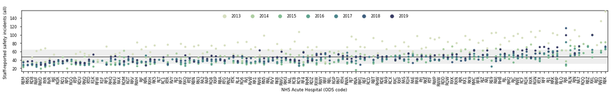

```python
profilePlot(df, 'si_all_rate', ylabel='Staff-reported safety incidents (all)  ')
plt.savefig('fig_profile_1.svg', format='svg', dpi=1200)
```

**Interpretation.** The hospital profile plots for staff-reported safety incidents (all severity levels) reveals (1) more incidents in 2013, (2) a distribution skewed towards low rates, (3) many hospitals with consistently low rates, (4) some hospitals with sometimes high, but also very variable rates, and (5) some hospitals have consistently high rates.

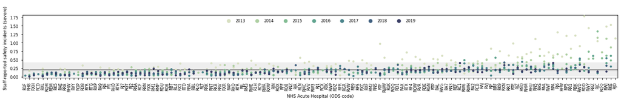

```python
profilePlot(df, 'si_severe_rate', ylabel='Staff-reported safety incidents (severe)  ')
plt.savefig('fig_profile_2.svg', format='svg', dpi=1200)
```

**Interpretation.** The hospital profile plots for staff-reported safety incidents (only severe) reveals (1) more severe incidents in 2013, (2) a distribution skewed towards low rates, (3) many hospitals with consistently low rates, (4) some hospitals with sometimes high, but also very variable rates, and (5) few hospitals with consistently high rates.

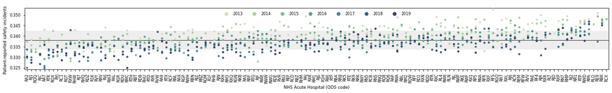

```python
profilePlot(df, 'ddr_safetyIncident', ylabel='Patient-reported safety incidents  ')
plt.savefig('fig_profile_3.svg', format='svg', dpi=1200)
```

**Interpretation.** The hospital profile plots for the patient-reported safety incident measure reveals (1) higher scores for 2013 and 2014, (2) a non-skewed distribution, (3) a trend for some hospitals to score fairly consistently high or low.

### Explore 'year'

In this section we explore variations in the variables across time.

```python
# create a violin plots
def plotViolins(df, cat, cont):
    plot_width = len(set(df[cat]))*2
    sns.set(rc={'figure.figsize':(plot_width,3)},
            style='whitegrid',
           palette=sns.cubehelix_palette(8, start=.5, rot=-.75))
    sns.violinplot(x=cat, y=cont, data=df, scale='count', cut=0)
    # add mean
    plt.axhline(y = df[cont].mean(), color = 'black', linewidth=1, zorder=0)
```

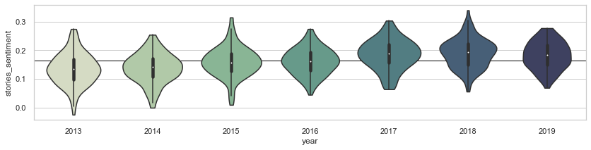

```python
plotViolins(df, 'year', 'stories_sentiment')
```

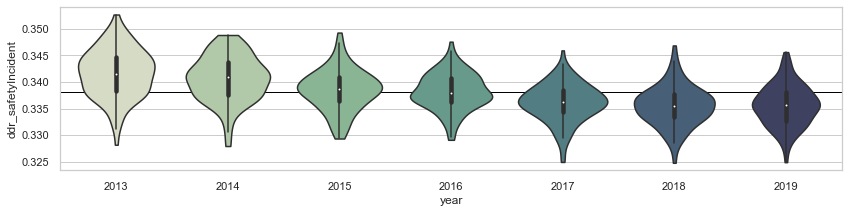

```python
plotViolins(df, 'year', 'ddr_safetyIncident')
```

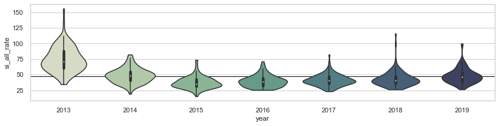

```python
plotViolins(df, 'year', 'si_all_rate')
```

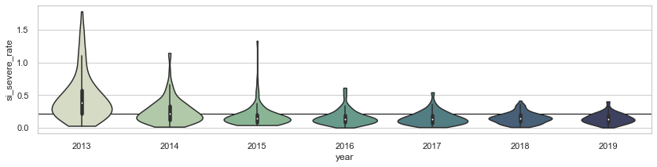

```python
plotViolins(df, 'year', 'si_severe_rate')
```

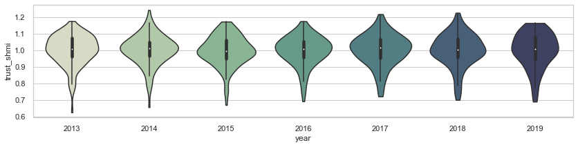

```python
plotViolins(df, 'year', 'trust_shmi')
```

**Interpretation.** There is evidence of significant variations by year. Specifically, patients' reviews have become more positive and report less severe safety incidents. Accordingly, it is important to control for 'year' in the analysis.

### Explore 'region'

In this section, we explore variation in the main variables by geographic region.

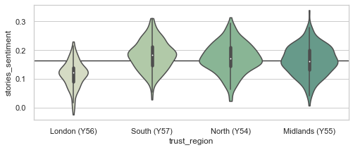

```python
plotViolins(df, 'trust_region', 'stories_sentiment')
```

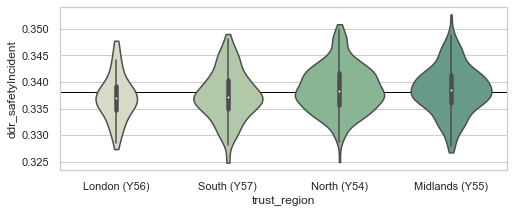

```python
plotViolins(df, 'trust_region', 'ddr_safetyIncident')
```

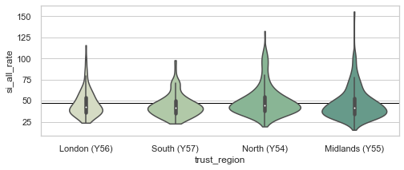

```python
plotViolins(df, 'trust_region', 'si_all_rate')
```

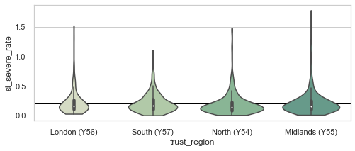

```python
plotViolins(df, 'trust_region', 'si_severe_rate')
```

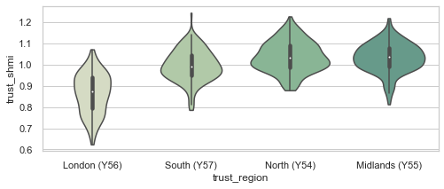

```python
plotViolins(df, 'trust_region', 'trust_shmi')
```

**Interpretation.** There is evidence of variation by region. Specifically, London is peculiarly low on both review sentiment and mortality. Accordingly, it is important to control for 'region' in the analysis.

## RQ1: Measure validity

To examine the validity of the patient-reported safety incident measure we score each item of feedback, select the highest (n=1000) and lowest (n=1000) scoring feedback and then manually code these for safety incidents. This allows us to construct a confusion matrix (high/low scoring vs yes/no manual coding of safety incidents).

### Save high/low scoring feedback to excel

This section extracts the feedback with the highest and lowest scores, identifies the sentence within each item of feedback that has the highest score, and links the feedback to the original online data. The output is saved as an excel file. This excel file was used for the manual coding, which was conducted directly in excel.

```python
# get sotries
df_stories = df_raw[['story_id', 'story']].copy()

# run spacy
df_stories['story_doc'] = [doc for doc in nlp.pipe(df_stories['story'])]

# split into sentences
df_stories['sentence'] = df_stories['story_doc'].apply(lambda x: [sent for sent in x.sents])
```

```python
# create a dataframe with one row per sentence
df_sent2 = df_stories.explode('sentence').drop_duplicates().copy()

# score sentences
createDDR(nlp, df_sent2, 'sentence', safetyIncident_targetTerms, 'sent_score')

# score stories
createDDR(nlp, df_sent2, 'story_doc', safetyIncident_targetTerms, 'story_score')

# add story length
df_sent2['wordcount'] = df_sent2['story_doc'].apply(len)

# filter for length
df_sent2 = df_sent2.loc[df_sent2['wordcount']>100, :].copy()

# sort & rank - by sentences & stories
df_sent2 = df_sent2.sort_values(['story_score', 'sent_score', ], ascending=False)

# select highest scoring sentence for each story
df_sent2 = df_sent2.drop_duplicates(subset='story_id', keep='first', ignore_index=True).copy()

# reset index = rank
df_sent2 = df_sent2.reset_index(drop=True).copy()
df_sent2['rank'] = df_sent2.index + 1

# convert sentence to text
df_sent2['sentence'] = [x.text for x in df_sent2['sentence']]

# select rows
#n_sent = df_sent2.shape[0]
high_scoring = list(range(0,1001))
low_scoring = list(range(len(df_sent2)-1001, len(df_sent2)+1))
ranks_to_keep = high_scoring+low_scoring

# create df
cols = ['rank', 'story_id', 'story_score', 'sent_score', 'sentence']
df_save = df_sent2.loc[df_sent2['rank'].isin(ranks_to_keep), cols].reset_index(drop=True).copy()
```

```python
# create excel
writer = pd.ExcelWriter('data_highest_lowest_scoring_feedback.xlsx', engine='xlsxwriter')
df_save.to_excel(writer, sheet_name='scored_feedback', index=False)
worksheet = writer.sheets['scored_feedback']

# get id for sentence column
col = df_save.columns.get_loc('sentence')

# create urls
for row in range(1, len(df_save['story_id'])+1): # skip first row with headings
    worksheet.write_url(row, col,
                        url='https://www.careopinion.org.uk/'+str(df_save['story_id'][row-1]),
                        # clip sentences longer than 100 char and add '...'
                        string=str(df_save['sentence'][row-1]) if len(str(df_save['sentence'][row-1]))<100 else str(df_save['sentence'][row-1][:100])+'...',
                        tip='Link to original review')
worksheet.set_column(col, col, 100)
writer.save();
```

### Load manual coded inter-rater reliability data

Having manually coded the data exported to excel (created in the previous section) this loads the 100 patient stories that were coded by both manual coders

```python
df_irr = pd.read_excel('data_interRaterReliability.xlsx', index_col='story_id')
df_irr.shape
df_irr.head(3)
```

```
(100, 12)
```

| story_id | 1a_safety_incident_all_x | 1b_safety_incident_severe_x | 2a_safety_investigation_any_x | 2b_safety_investigation_patient_initiated_x | 3a_report_safety_question_dismissed_x | 3b_asking_safety_questions_x | 1a_safety_incident_all_y | 1b_safety_incident_severe_y | 2a_safety_investigation_any_y | 2b_safety_investigation_patient_initiated_y | 3a_report_safety_question_dismissed_y | 3b_asking_safety_questions_y |
| --- | --- | --- | --- | --- | --- | --- | --- | --- | --- | --- | --- | --- |
| 83686 | 0 | 0 | 0 | 0 | 0 | 0 | 0 | 0 | 0 | 0 | 0 | 0 |
| 86686 | 0 | 0 | 0 | 0 | 0 | 0 | 0 | 0 | 0 | 0 | 0 | 0 |
| 87199 | 0 | 0 | 0 | 0 | 0 | 0 | 0 | 0 | 0 | 0 | 0 | 0 |

### Inter-rater reliability for RQ1

**safety_incident_all.** Was there a safety incident?

**safety_incident_severe.** Was there a severe safety incident?

```python
safety_incident_vars = ['1a_safety_incident_all', '1b_safety_incident_severe',]
```

```python
# cronbach alpha
for var in safety_incident_vars:
    print('\n',var)
    df_ = df_irr[[x for x in df_irr.columns if var in x]]
    ca = pingouin.cronbach_alpha(data=df_, ci=0.95)
    print('Cronbach Alpha = ', round(ca[0], 3), '    95% CI = ', ca[1])
```

```
 1a_safety_incident_all
Cronbach Alpha =  0.891     95% CI =  [0.837 0.926]

 1b_safety_incident_severe
Cronbach Alpha =  0.716     95% CI =  [0.578 0.809]
```

### Precision & recall

```python
# load all the manually coded data
df_man = pd.read_excel('data_manualClassifications.xlsx', index_col='story_id')
df_man = df_man.drop(['story_score', 'sent_score', 'sentence'], axis=1).copy()
df_man.shape
df_man.head(3)
```

```
(2000, 7)
```

| story_id | high_score | 1a_safety_incident_all | 1b_safety_incident_severe | 2a_safety_investigation_any | 2b_safety_investigation_patient_initiated | 3a_report_safety_question_dismissed | 3b_asking_safety_questions |
| --- | --- | --- | --- | --- | --- | --- | --- |
| 81994 | 1 | 1 | 1 | 0 | 0 | 0 | 0 |
| 82164 | 1 | 1 | 1 | 0 | 0 | 0 | 0 |
| 82216 | 1 | 0 | 0 | 0 | 0 | 0 | 0 |

```python
# create confusion matricies
for var in safety_incident_vars:
    pd.crosstab(df_man[var].astype('boolean'), df_man['high_score'], margins=True)
```

| high_score 1a_safety_incident_all | 0 | 1 | All |
| --- | --- | --- | --- |
| False | 984 | 315 | 1299 |
| True | 16 | 685 | 701 |
| All | 1000 | 1000 | 2000 |

| high_score 1b_safety_incident_severe | 0 | 1 | All |
| --- | --- | --- | --- |
| False | 1000 | 820 | 1820 |
| True | 0 | 180 | 180 |
| All | 1000 | 1000 | 2000 |

```python
# select the data
df_si = df_man[['high_score', '1a_safety_incident_all', '1b_safety_incident_severe']].dropna().copy()
df_si.head(3)
```

| story_id | high_score | 1a_safety_incident_all | 1b_safety_incident_severe |
| --- | --- | --- | --- |
| 81994 | 1 | 1 | 1 |
| 82164 | 1 | 1 | 1 |
| 82216 | 1 | 0 | 0 |

```python
# precision, recall and fscore for 'safety incidents (all)'
from sklearn.metrics import precision_recall_fscore_support
precision_recall_fscore_support(df_si['1a_safety_incident_all'], df_si['high_score'],  average='binary')
```

```
(0.685, 0.9771754636233951, 0.805408583186361, None)
```

```python
# precision, recall and fscore for 'safety incidents (severe)'
from sklearn.metrics import precision_recall_fscore_support
precision_recall_fscore_support(df_si['1b_safety_incident_severe'], df_si['high_score'], average='binary')
```

```
(0.18, 1.0, 0.3050847457627119, None)
```

## RQ2: Unnoticed & unresolved incidents

### Unnoticed incidents

The manual coding used in this analysis is:

**safety_investigation_any.** Does the feedback refer to a formal safety investigation?

**safety_investigation_patient_initiated.** Is the patient reported as initiating a safety investigation?

```python
unoticed_vars = ['2a_safety_investigation_any',
                 '2b_safety_investigation_patient_initiated',]
```

```python
# check cronbach alpha for manual coding
for var in unoticed_vars:
    print('\n',var)
    df_ = df_irr[[x for x in df_irr.columns if var in x]]
    ca = pingouin.cronbach_alpha(data=df_, ci=0.95)
    print('Cronbach Alpha = ', round(ca[0], 3), '    95% CI = ', ca[1])
```

```
 2a_safety_investigation_any
Cronbach Alpha =  0.921     95% CI =  [0.882 0.947]

 2b_safety_investigation_patient_initiated
Cronbach Alpha =  0.921     95% CI =  [0.882 0.947]
```

```python
# get n and % for manual coding
for var in unoticed_vars:
    print('Number')
    pd.crosstab(df_man[var].astype('boolean'), df_man['high_score'], margins=True)
    print('Percent')
    pd.crosstab(df_man[var].astype('boolean'), df_man['high_score'], margins=True, normalize='columns').round(2)*100
```

```
Number
```

| high_score 2a_safety_investigation_any | 0 | 1 | All |
| --- | --- | --- | --- |
| False | 993 | 889 | 1882 |
| True | 7 | 111 | 118 |
| All | 1000 | 1000 | 2000 |

```
Percent
```

| high_score 2a_safety_investigation_any | 0 | 1 | All |
| --- | --- | --- | --- |
| False | 99.0 | 89.0 | 94.0 |
| True | 1.0 | 11.0 | 6.0 |

```
Number
```

| high_score 2b_safety_investigation_patient_initiated | 0 | 1 | All |
| --- | --- | --- | --- |
| False | 993 | 894 | 1887 |
| True | 7 | 106 | 113 |
| All | 1000 | 1000 | 2000 |

```
Percent
```

| high_score 2b_safety_investigation_patient_initiated | 0 | 1 | All |
| --- | --- | --- | --- |
| False | 99.0 | 89.0 | 94.0 |
| True | 1.0 | 11.0 | 6.0 |

### Unresolved incidents

The manual coding used in this analysis is:

**report_safety_questions_dismissed.** Does the feedback report safety questions being dismissed?

**asking_safety_questions.** Does the feedback directly ask (not report asking) safety questions?

```python
unresolved_vars = ['3a_report_safety_question_dismissed',
                   '3b_asking_safety_questions']
```

```python
# check cronbach alpha for manual coding
for var in unresolved_vars:
    print('\n',var)
    df_ = df_irr[[x for x in df_irr.columns if var in x]]
    ca = pingouin.cronbach_alpha(data=df_, ci=0.95)
    print('Cronbach Alpha = ', round(ca[0], 3), '    95% CI = ', ca[1])
```

```
 3a_report_safety_question_dismissed
Cronbach Alpha =  0.63     95% CI =  [0.45  0.751]

 3b_asking_safety_questions
Cronbach Alpha =  0.742     95% CI =  [0.616 0.826]
```

```python
# get n and % for manual coding
for var in unresolved_vars:
    print('Number')
    pd.crosstab(df_man[var].astype('boolean'), df_man['high_score'], margins=True)
    print('Percent')
    pd.crosstab(df_man[var].astype('boolean'), df_man['high_score'], margins=True, normalize='columns').round(2)*100
```

```
Number
```

| high_score 3a_report_safety_question_dismissed | 0 | 1 | All |
| --- | --- | --- | --- |
| False | 998 | 787 | 1785 |
| True | 2 | 213 | 215 |
| All | 1000 | 1000 | 2000 |

```
Percent
```

| high_score 3a_report_safety_question_dismissed | 0 | 1 | All |
| --- | --- | --- | --- |
| False | 100.0 | 79.0 | 89.0 |
| True | 0.0 | 21.0 | 11.0 |

```
Number
```

| high_score 3b_asking_safety_questions | 0 | 1 | All |
| --- | --- | --- | --- |
| False | 997 | 939 | 1936 |
| True | 3 | 61 | 64 |
| All | 1000 | 1000 | 2000 |

```
Percent
```

| high_score 3b_asking_safety_questions | 0 | 1 | All |
| --- | --- | --- | --- |
| False | 100.0 | 94.0 | 97.0 |
| True | 0.0 | 6.0 | 3.0 |

**Interpretation**

9% of the feedback reporting safety incidents included direct (i.e., non-reported) safety questions. For example, 'why was my husband not given his medication?' and 'when will someone explain the circumstances around her death?'. Patients asking such questions online suggest that the hospital concerned has failed to provide satisfactory explanations for events.

## RQ3: Correlations between safety incident measures

An analysis was conducted to examine the correlations between measures, especially between the staff-reported safety incidents and the novel measure of patient-reported safety incidents. The unit of analysis was a hospital-year (N = 792), representing 134 distinct hospitals (from a population of 139) over the period from 2013 to 2019 (this missing hospital-years was due to trust-years with less than 10k words of patient feedback being excluded).

```python
# get data to correlate
vars_to_correlate = [
    'year',
    'trust_spells',
    'trust_caseSeverity',
    'wordcount',
    'stories_sentiment',
    'ddr_safetyIncident',
    'si_all_rate',
    'si_severe_rate',
    'trust_shmi']

df_plot = df[vars_to_correlate].copy()

# rename variables
rename_cols = {'trust_spells': 'Hospital spells',
               'trust_caseSeverity': 'Hospital case severity',
               'wordcount': 'Patient feedback wordcount',
               'stories_sentiment': 'Patient feedback sentiment',
               'ddr_safetyIncident': 'Patient-reported incidents',
               'si_all_rate': 'Staff-reported incidents (all)',
               'si_severe_rate': 'Staff-reported incidents (severe)',
               'trust_shmi': 'Hospital-level mortality'}
df_plot.rename(columns=rename_cols, inplace=True)
```

```python
# function to print multi-year correlations in plot
def corrfunc(x, y, **kws):
    if (len(x)>1) & (len(y)>1):
        r, p = stats.spearmanr(x, y)
    else: # if there is no data
        r = 0
        p = 1
    ax = plt.gca()
    # count how many annotations are already present
    n = len([c for c in ax.get_children() if
                  isinstance(c, matplotlib.text.Annotation)])
    pos = (.25, .8 - .1*n)

    # convert r to conditional string to create extra space to counterbalance '-' neg values
    r = str(round(r, 2)) if r <0 else ' '+str(round(r,2))
    r = r.replace('0.', '.')

    if p < 0.001:
        ax.annotate("{}:  r = {}***".format(kws['label'], r), xy=pos, xycoords=ax.transAxes).set_weight('bold')
    elif p < 0.01:
        ax.annotate("{}:  r = {}**".format(kws['label'], r), xy=pos, xycoords=ax.transAxes).set_weight('bold')
    elif p <= 0.05:
        ax.annotate("{}:  r = {}*".format(kws['label'], r), xy=pos, xycoords=ax.transAxes).set_weight('bold')
    elif p==1: # if there is no data
        ax.annotate("{}: No data".format(kws['label']), xy=pos, xycoords=ax.transAxes)
    else:
        ax.annotate("{}:  r = {}".format(kws['label'], r), xy=pos, xycoords=ax.transAxes)
```

```python
len(set(df_plot['year']))
```

```
7
```

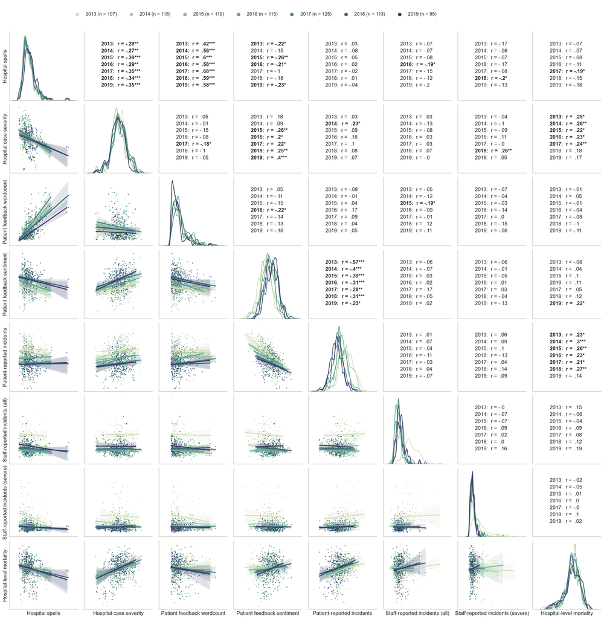

```python
# create correlation plot
sns.reset_defaults()
sns.set_style("whitegrid", {'axes.grid' : False}) # 'white' for bold axes
sns.set_context("notebook")
g = sns.PairGrid(df_plot,
                 hue='year',
                 layout_pad=0, # subplot padding
                 palette=sns.cubehelix_palette(8, start=.5, rot=-.75),
                 diag_sharey=False) # share y axis on diagnal
g.map_lower(sns.regplot, scatter_kws={'s':1, 'alpha':1});
g.map_diag(sns.kdeplot, kernel = 'cos', legend = True)
g.map_upper(corrfunc)
g.set(yticks=[], xticks=[]) # remove ticks

g.add_legend(title=' ', loc='upper center', ncol=7, bbox_to_anchor=(0.315,1)) # position legend
g.fig.subplots_adjust(top=0.95) # lower the top of image to make place for legend
for lh in g._legend.legendHandles: # change alpha and size of legend
    lh.set_alpha(1)
    lh._sizes = [50]

# create custom legend text to include n per year
year_groups = df_plot['year'].value_counts().sort_index()
year_groups = zip(year_groups.index, year_groups.values)
new_legend = []
for x in year_groups:
    new_legend.append(str(x[0]) + ' (n = ' + str(x[1]) + ')')
for t, l in zip(g._legend.texts, new_legend): t.set_text(l) # apply custom legend text
#g._legend.set_title('Year (number of hospitals)')
plt.show();

g.savefig('fig_correlations.svg', format='svg', dpi=1200)
```

**Interpretation**

**Hospital spells** is consistently associated with increased volumes of patient feedback (indicated by wordcount) and inconsistently associated with reduced feedback sentiment.

**Hospital case severity** is fairly consistently associated with more positive patient sentiment and increased hospital-level mortality rates.

**Patient feedback sentiment** is consistently associated with fewer patient-reported safety incidents.

**Patient-reported safety incidents** is fairly consistently associated with increased hospital-level mortality rates.

**RQ3.** There is no evidence for any statistically significant association between the patient-reported safety incident measure and the rates of staff-reported safety incidents (all or severe).

## RQ4: Predicting hospital-level mortality

In this section, we test whether staff-reported safety incidents and the measure of patient-reported incidents were predictive of hospital-level mortality taking account of multiple controls. The unit of analysis was a hospital-year (N = 792), representing 134 distinct hospitals (from a population of 139) over the period from 2013 to 2019 (this missing hospital-years was due to trust-years with less than 10k words of patient feedback being excluded).

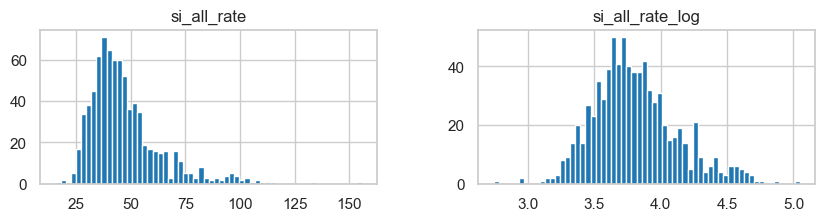

```python
# due to the skewed distribution of staff-reported safety incidents (all), we convert to a log score
df['si_all_rate_log'] = np.log(df['si_all_rate']+0.01)
df.hist(bins=60, layout=(1,2), column=['si_all_rate', 'si_all_rate_log'], figsize=(10, 2));
```

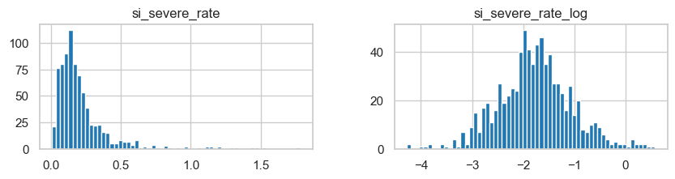

```python
# due to the skewed distribution of staff-reported safety incidents (severe), we convert to a log score
df['si_severe_rate_log'] = np.log(df['si_severe_rate']+0.01)
df.hist(bins=60, layout=(1,2), column=['si_severe_rate', 'si_severe_rate_log'], figsize=(10, 2));
```

A linear mixed effects model was constructed using year (2013-2019 inclusive) and region (North, Midlands, London, South) as crossed random effects based on exploratory analysis indicating differences in some variables across these factors. The model also controlled for the total number of hospital spells, total word count in the patient feedback, and a text-based measure of overall positive/negative sentiment in the patient feedback (fixed effects). All numeric explanatory variables were linearly normalized to a range of 0 to 1, i.e. so that the minimum value in the data was transformed to 0 and the maximum value to 1.

```python
# create mixed linear model
target = ['trust_shmi']
controls = ['trust_spells', 'trust_caseSeverity', 'wordcount', 'stories_sentiment']
predictors = ['si_all_rate_log', 'si_severe_rate_log', 'ddr_safetyIncident']

# order
vars_in_order = controls+predictors
vars_in_order.reverse()

# normalize data 0-1 for coeffient plotting
df_norm =df[['trust_id', 'year', 'trust_region']+vars_in_order+target].copy()
df_norm.dropna(inplace=True)
vars_to_normalize = vars_in_order

for var in vars_to_normalize:
    df_norm[var] = (df_norm[var]-df_norm[var].min())/(df_norm[var].max()-df_norm[var].min())

# create formula
formula = target[0]+' ~ '+' + '.join(vars_in_order)
print(formula)

# create grouping varibales
vcf = {"trust_region": "0 + C(trust_region)", "year": "0 + C(year)"}

# add an artificial group
df_norm['group'] = 1

# model
model = sm.MixedLM.from_formula(formula, df_norm, re_formula= '0', vc_formula = vcf, groups = 'group')
result = model.fit()
result.summary()
```

```
trust_shmi ~ ddr_safetyIncident + si_severe_rate_log + si_all_rate_log + stories_sentiment + wordcount + trust_caseSeverity + trust_spells
```

| Model: | MixedLM | Dependent Variable: | trust_shmi |
| --- | --- | --- | --- |
| No. Observations: | 792 | Method: | REML |
| No. Groups: | 1 | Scale: | 0.0052 |
| Min. group size: | 792 | Log-Likelihood: | 921.3839 |
| Max. group size: | 792 | Converged: | Yes |
| Mean group size: | 792.0 |  |  |

|  | Coef. | Std.Err. | z | P>\|z\| | [0.025 | 0.975] |
| --- | --- | --- | --- | --- | --- | --- |
| Intercept | 0.979 | 0.048 | 20.273 | 0.000 | 0.884 | 1.073 |
| ddr_safetyIncident | 0.080 | 0.022 | 3.601 | 0.000 | 0.036 | 0.123 |
| si_severe_rate_log | -0.011 | 0.020 | -0.569 | 0.569 | -0.050 | 0.027 |
| si_all_rate_log | 0.002 | 0.024 | 0.066 | 0.947 | -0.045 | 0.048 |
| stories_sentiment | -0.055 | 0.024 | -2.298 | 0.022 | -0.102 | -0.008 |
| wordcount | 0.037 | 0.020 | 1.821 | 0.069 | -0.003 | 0.077 |
| trust_caseSeverity | 0.030 | 0.019 | 1.562 | 0.118 | -0.008 | 0.067 |
| trust_spells | -0.109 | 0.032 | -3.439 | 0.001 | -0.171 | -0.047 |
| trust_region Var | 0.006 | 0.072 |  |  |  |  |
| year Var | 0.000 | 0.002 |  |  |  |  |

```python
def coefPlot(result, rename={}, figsize=(6, 3), save_file = None):
    coefs = result.params
    coefs.rename(rename, inplace=True)
    coefs.drop(labels = ['Intercept', 'year Var', 'trust_region Var'], inplace = True)
    ci = result.conf_int()
    errors = (ci[1] - ci[0]) / 2
    errors.rename(rename, inplace=True)
    errors.drop(labels = ['Intercept', 'year Var', 'trust_region Var'], inplace = True)
    plt.clf()
    plt.figure(figsize=figsize)
    plt.errorbar(x = coefs, y = coefs.index, xerr = errors, fmt = 'o', zorder=2, ecolor='black', color='black')
    plt.axvline(x = 0, color = 'black', zorder=1)
    plt.title(f'Scaled parameter estimates with 95% confidence intervals\n')
    if save_file != None:
        plt.savefig(save_file, bbox_inches='tight');
```

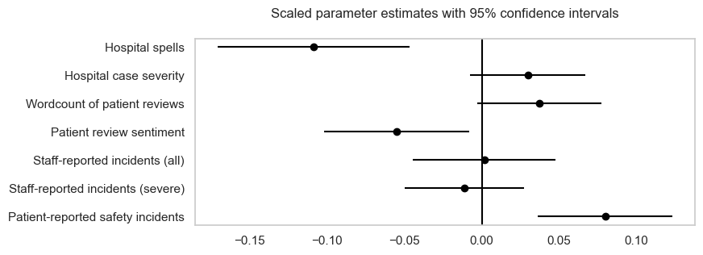

```python
# rename variables
rename_cols = {'trust_spells': 'Hospital spells',
               'trust_caseSeverity': 'Hospital case severity',
               'wordcount': 'Wordcount of patient reviews',
               'stories_sentiment': 'Patient review sentiment',
               'si_all_rate_log': 'Staff-reported incidents (all)',
               'si_severe_rate_log': 'Staff-reported incidents (severe)',
               'ddr_safetyIncident': 'Patient-reported safety incidents'}

coefPlot(result, rename_cols, figsize=(8, 3));
plt.savefig('fig_parameter_estimates.svg', format='svg', dpi=1200, bbox_inches='tight')
```

**Interpretation**

**Hospital spells.** As the patient-throughput increases, the Summary Hospital-level Mortality Indicator (SHMI) decreases (i.e., there are fewer deaths than expected). This suggests that large hospitals have lower than expected mortality rates.

**Hospital case severity.** Hospitals with more severe cases have a non-significant tendency toward higher SHMI.

**Patient feedback wordcount.** Hospitals where patients write longer feedback have a non-significant tendency toward higher SHMI.

**Patient feedback sentiment.** There is a weak tendency for positive sentiment in feedback to be a associated with lower SHMI.

**Staff-reported safety incidents (all & severe).** There is no discernible association between staff-reported safety incidents (either all or severe) and hospital-level mortality rates.

**RQ4: Patient-reported safety incidents.** There is an association between patients reporting safety incidents and an increase in SHMI that is independent of hospital characteristics (spells, case severity) and feedback sentiment.

# Robustness checks

According to [McKenny et al (2018)](https://doi.org/10.1177%2F0149206316657594), natural language processing techniques are associated with various types of error, including:

1. 'Transient error' due to variations in language use over time.
2. 'Specific factor error' due to choices made when compiling word lists.
3. 'Algorithm error' due to variations in how algorithms operate.

## Transient error

Temporal variation in language use is inherent in human language and cannot be eliminated. Instead, it needs to be investigated and controlled for. The current analysis controls for transient error, by having year as a control variable. However, this control, does not provide much insight into transient error. In this section, we explore transient error in the patient-reported safety incident measure.

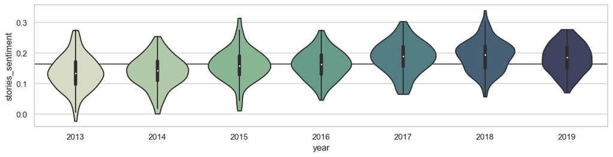

```python
plotViolins(df, 'year', 'stories_sentiment')
```

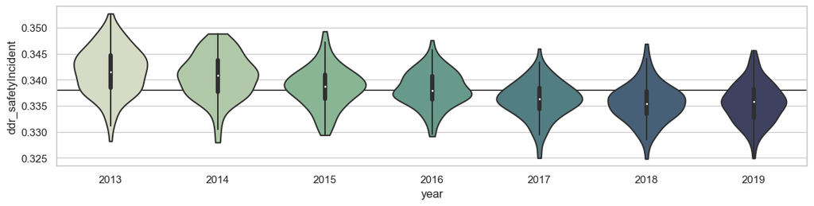

```python
plotViolins(df, 'year', 'ddr_safetyIncident')
```

Examining the temporal trends for sentiment and safety incidents in the patient feedback text reveals trends towards increasing sentiment and decreasing safety incidents.

### Test-retest reliability

Following [McKenny et al (2018)](https://doi.org/10.1177%2F0149206316657594), we quantify transient error by calculating the correlation coefficients for the safety incident measure for each consecutive pair of years, and averaging the correlation coefficients.

```python
# get sorted list of years
years = sorted(list(set(df['year'])))
# create consecutive pairs
year_pairs = list(zip(years[:-1], years[1:]))
list(year_pairs)
```

```
[(2013, 2014),
 (2014, 2015),
 (2015, 2016),
 (2016, 2017),
 (2017, 2018),
 (2018, 2019)]
```

```python
# create wide df
df_wide = df[['year', 'trust_id', 'ddr_safetyIncident']].pivot(index='trust_id', columns='year')
df_wide.columns = df_wide.columns.droplevel()
df_wide.head(3)
```

| year trust_id | 2013 | 2014 | 2015 | 2016 | 2017 | 2018 | 2019 |
| --- | --- | --- | --- | --- | --- | --- | --- |
| R1F | NaN | NaN | NaN | NaN | 0.336954 | NaN | NaN |
| R1H | 0.344195 | 0.336697 | 0.338949 | 0.338208 | 0.336577 | 0.336353 | 0.338124 |
| R1K | NaN | NaN | 0.332476 | 0.332114 | 0.336930 | 0.336007 | 0.335463 |

```python
correlations = []
for pair in year_pairs:
    correlation = df_wide[list(pair)[0]].corr(df_wide[list(pair)[1]]).round(3)
    correlations.append(correlation)
    print(pair, '  Pearson corr =  ', correlation)
```

```
(2013, 2014)   Pearson corr =   0.408
(2014, 2015)   Pearson corr =   0.428
(2015, 2016)   Pearson corr =   0.463
(2016, 2017)   Pearson corr =   0.579
(2017, 2018)   Pearson corr =   0.443
(2018, 2019)   Pearson corr =   0.435
```

```python
# mean correlation
sum(correlations)/len(correlations)
```

```
0.4593333333333333
```

Correlating the safety incident scores for each pair of consecutive years revealed potentially substantial and consistent transient error. The test-retest correlations ranged from 0.408 to 0.579, with a mean correlation of 0.459. Thus up to 54% (1-mean correlation) of the variance is due to transient error.

[McKenny et al (2018)](https://doi.org/10.1177%2F0149206316657594) report comparable rates of transient error and note that measures of transient error can be artificially high if there are changes in the underlying construct (e.g., hospital improvements). The violin plots of changes in sentiment and patient-reported safety incidents over time suggest that there may be changes in sentiment and safety incidents over time. This could be due to real changes in the phenomena, or changes in language use.

The implications of this transient error are: (1) it is necessary to control for changes over time, (2) the language model and target terms should be kept up-to-date to capture changes in language use.

## Specific factor error

There are necessarily many decisions required to do natural language processing (e.g., how text is cleaned and prepared, the choice of key words and concepts to explore, and how specific concepts are measured). Our analysis entailed minimal pre-processing of the texts (we did not remove or change any of the original text). However, we made many decisions when choosing our target terms. Although we followed a clearly laid out 4-step methodology (described above), different choices of target terms would have changed the results, and perhaps the overall finding. In this section we assess the extent to which the findings may be an byproduct of our choice of target terms.

To assess the extent to which the findings were an byproduct of the chosen target terms, we re-ran the mixed model with (1) a random selection of half of our target terms and (2) the rejected target terms.

### Analysis with half of the target terms

```python
# convert target terms to list
list_target_terms = safetyIncident_targetTerms.split()

# randomly sample half of the list
random.seed(857649)
list_target_terms = random.sample(list_target_terms, k=int(len(list_target_terms)/2))

# create string
half_target_terms = ' '.join(list_target_terms)

# print sample
half_target_terms
```

```
'readmitted killing succumbed mortally disfigured scarred killed dying murderous overmedicated'
```

```python
# score the data
createDDR(nlp, df, 'stories_doc', half_target_terms, 'ddr_half')
```

```python
# define variables
target = ['trust_shmi']
controls = ['trust_spells', 'trust_caseSeverity', 'wordcount', 'stories_sentiment',]
predictors = ['si_all_rate_log', 'si_severe_rate_log', 'ddr_half']
```

```python
# select data
df_half =df.loc[:, ['trust_id', 'year', 'trust_region']+controls+predictors+target].copy()

# normalize data 0-1 for coeffient plotting
for var in controls+predictors:
    df_half[var] = (df_half[var]-df_half[var].min())/(df_half[var].max()-df_half[var].min())

# create formula
formula = target[0]+' ~ '+' + '.join(controls+predictors)
print(formula)

# create groupings
vcf = {"trust_region": "0 + C(trust_region)", "year": "0 + C(year)"}
df_half['group'] = 1

model = sm.MixedLM.from_formula(formula, df_half, re_formula= '0', vc_formula = vcf, groups = 'group')
result_half = model.fit()
result_half.summary()
```

```
trust_shmi ~ trust_spells + trust_caseSeverity + wordcount + stories_sentiment + si_all_rate_log + si_severe_rate_log + ddr_half
```

| Model: | MixedLM | Dependent Variable: | trust_shmi |
| --- | --- | --- | --- |
| No. Observations: | 792 | Method: | REML |
| No. Groups: | 1 | Scale: | 0.0053 |
| Min. group size: | 792 | Log-Likelihood: | 921.0974 |
| Max. group size: | 792 | Converged: | Yes |
| Mean group size: | 792.0 |  |  |

|  | Coef. | Std.Err. | z | P>\|z\| | [0.025 | 0.975] |
| --- | --- | --- | --- | --- | --- | --- |
| Intercept | 0.980 | 0.048 | 20.324 | 0.000 | 0.886 | 1.075 |
| trust_spells | -0.108 | 0.032 | -3.433 | 0.001 | -0.170 | -0.047 |
| trust_caseSeverity | 0.031 | 0.019 | 1.606 | 0.108 | -0.007 | 0.068 |
| wordcount | 0.037 | 0.020 | 1.821 | 0.069 | -0.003 | 0.077 |
| stories_sentiment | -0.056 | 0.024 | -2.315 | 0.021 | -0.103 | -0.009 |
| si_all_rate_log | 0.001 | 0.024 | 0.056 | 0.956 | -0.045 | 0.047 |
| si_severe_rate_log | -0.011 | 0.020 | -0.572 | 0.567 | -0.050 | 0.027 |
| ddr_half | 0.079 | 0.023 | 3.508 | 0.000 | 0.035 | 0.123 |
| trust_region Var | 0.006 | 0.072 |  |  |  |  |
| year Var | 0.000 | 0.001 |  |  |  |  |

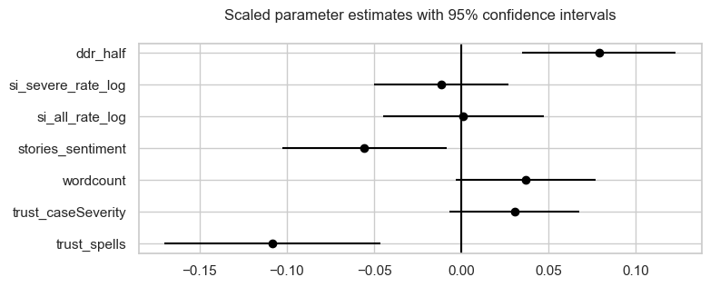

```python
coefPlot(result_half, figsize=(8, 3));
```

**Interpretation**  
Randomly removing half of the target terms, and re-running the analysis, does not materially impact the findings. This robustness of the findings is due to the close proximity of the target terms within the vector space, and thus removing target terms has minimal impact on the average vector for the target terms.

### Analysis with extra target terms

Our second approach to assess the extent to which our findings are an artefact of the target terms chosen, we used the expanded list of target terms that were deemed valid but before any selection on the basis of reliability. This increased the number of target terms from 21 to 43.

```python
# view expanded list of target terms, including terms rejected for low reliability
nlp(valid_targetTerms)
```

```
dangerous dead deadly deceased died dieing disfigured dying error grave harmed incapacitated incompetent
killed killing maimed malpractice misdiagnosed misdiagnosing misidentified misidentifying misinterpreted
misjudged misled mistake mistaken mortally murdered murdering murderous mutilated overmedicated perished
preventable readmission readmitted readmitting scarred succumb succumbed succumbing traumatised wrongly
```

```python
createDDR(nlp, df, 'stories_doc', valid_targetTerms, 'ddr_expanded')
```

```python
# define variables
target = ['trust_shmi']
controls = ['trust_spells', 'trust_caseSeverity', 'wordcount', 'stories_sentiment',]
predictors = ['si_all_rate_log', 'si_severe_rate_log', 'ddr_expanded']
```

```python
# select data
df_expanded =df.loc[:, ['trust_id', 'year', 'trust_region']+controls+predictors+target].copy()

# normalize data 0-1 for coeffient plotting
for var in controls+predictors:
    df_expanded[var] = (df_expanded[var]-df_expanded[var].min())/(df_expanded[var].max()-df_expanded[var].min())

# create formula
formula = target[0]+' ~ '+' + '.join(controls+predictors)
print(formula)

# create groupings
vcf = {"trust_region": "0 + C(trust_region)", "year": "0 + C(year)"}
df_expanded['group'] = 1

model = sm.MixedLM.from_formula(formula, df_expanded, re_formula= '0', vc_formula = vcf, groups = 'group')
result_expanded = model.fit()
result_expanded.summary()
```

```
trust_shmi ~ trust_spells + trust_caseSeverity + wordcount + stories_sentiment + si_all_rate_log + si_severe_rate_log + ddr_expanded
```

| Model: | MixedLM | Dependent Variable: | trust_shmi |
| --- | --- | --- | --- |
| No. Observations: | 792 | Method: | REML |
| No. Groups: | 1 | Scale: | 0.0053 |
| Min. group size: | 792 | Log-Likelihood: | 916.9251 |
| Max. group size: | 792 | Converged: | Yes |
| Mean group size: | 792.0 |  |  |

|  | Coef. | Std.Err. | z | P>\|z\| | [0.025 | 0.975] |
| --- | --- | --- | --- | --- | --- | --- |
| Intercept | 1.000 | 0.050 | 20.180 | 0.000 | 0.903 | 1.097 |
| trust_spells | -0.110 | 0.032 | -3.464 | 0.001 | -0.173 | -0.048 |
| trust_caseSeverity | 0.034 | 0.019 | 1.776 | 0.076 | -0.004 | 0.072 |
| wordcount | 0.039 | 0.021 | 1.874 | 0.061 | -0.002 | 0.079 |
| stories_sentiment | -0.069 | 0.025 | -2.726 | 0.006 | -0.118 | -0.019 |
| si_all_rate_log | -0.002 | 0.023 | -0.082 | 0.934 | -0.047 | 0.043 |
| si_severe_rate_log | -0.009 | 0.020 | -0.466 | 0.641 | -0.048 | 0.029 |
| ddr_expanded | 0.044 | 0.023 | 1.951 | 0.051 | -0.000 | 0.089 |
| trust_region Var | 0.007 | 0.075 |  |  |  |  |
| year Var | 0.000 | 0.001 |  |  |  |  |

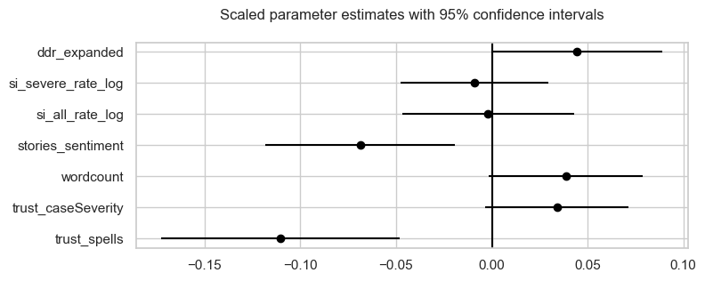

```python
coefPlot(result_expanded, figsize=(8, 3));
```

## Algorithm error

### Using a custom language model

Our main study used a large, robust, and publicly available language model [(spaCy, 2020)](https://github.com/explosion/spacy-models/releases//tag/en_core_web_lg-2.3.1) so as to test our predictions with as few degrees of freedom as possible. However, it is widely recognised that such generic models are sub-optimal in specific cases. Biases can be introduced into these generic models through peculiar statistical patterns in the input data. The language model we used was trained on [OntoNotes](https://catalog.ldc.upenn.edu/LDC2013T19), which contains a many news articles and broadcasts from 2013, and [GloVe Common Crawl](https://nlp.stanford.edu/projects/glove/) which contains a lot of webpage text. These training datasets are, arguably, quite far removed from patient feedback that is very domain specific.

To check whether there was a bias in the language model that materially impacted our findings, we trained our own language model. Because the patient feedback of acute trusts only comprised about 20 million words, and it is recommended to have at least 100 million words to build a language model, we expanded our corpus of patient feedback to include all the feedback available via the Care Opinion API (i.e., including feedback on non-acute NHS organisations). This yielded a dataset of over 400k items of patient feedback, comprising 58 million words. Although still small, this dataset is highly tailored to our interest and thus deemed viable to create a custom language model. The language model was created using the Word2Vec algorithm, yielding a model with 54,337 unique tokens in 300 dimensions.

```python
custom_location = r"C:\Dropbox\2_Research\_Python\_TOOLS_Make_embeddings\word_embedding_models\word_embedding_v5_onlyCareOpinionStories"

nlp2 = spacy.load(custom_location)
sentencizer = nlp2.create_pipe("sentencizer")
nlp2.add_pipe(sentencizer)
```

```python
# check the custom embeddings
target_term = 'died'

# compare target_term to each test sentence
for sentence in test_sentences:
    score = np.round(nlp2(sentence).similarity(nlp2(target_term)), 2)
    print("Similarity to 'died':  {:<6}  '{:}'".format(str(score), sentence))
```

```
Similarity to 'died':  -0.04   'Superb excellent ++'
Similarity to 'died':  -0.07   'easy car park'
Similarity to 'died':  0.01    'he was not happy'
Similarity to 'died':  0.3     'she was dying'
Similarity to 'died':  0.47    'he died very happy'
Similarity to 'died':  0.71    'he died'
```

```python
# get a copy of the data
df_custom = df.copy()
df_custom.head(3)
```

|  | year | trust_id | trust_region | trust_spells | trust_shmi | trust_caseSeverity | si_all_n | si_all_rate | si_severe_n | si_severe_rate | stories_n | stories | stories_doc | wordcount | stories_sentiment | ddr_safetyIncident | si_all_rate_log | si_severe_rate_log | ddr_half | ddr_expanded |
| --- | --- | --- | --- | --- | --- | --- | --- | --- | --- | --- | --- | --- | --- | --- | --- | --- | --- | --- | --- | --- |
| 0 | 2013 | R1H | London (Y56) | 163970 | 0.793 | 0.027445 | 16941 | 71.889600 | 81 | 0.343726 | 266 | I have been feeling dizzy since early Septembe... | (I, have, been, feeling, dizzy, since, early, ... | 55630 | 0.006 | 0.344195 | 4.275271 | -1.039233 | 0.352077 | 0.397230 |
| 1 | 2013 | RA2 | South (Y57) | 47409 | 0.911 | 0.029346 | 3993 | 55.300114 | 10 | 0.138493 | 80 | I would like to express my sincere thanks to ... | ( , I, would, like, to, express, my, sincere, ... | 13790 | 0.204 | 0.331203 | 4.012956 | -1.907220 | 0.339499 | 0.384341 |
| 2 | 2013 | RA7 | South (Y57) | 72110 | 0.951 | 0.025589 | 11918 | 96.477807 | 47 | 0.380471 | 92 | My wife was due to have an operation tomorrow... | ( , My, wife, was, due, to, have, an, operatio... | 15212 | 0.169 | 0.342951 | 4.569417 | -0.940401 | 0.350853 | 0.395688 |

```python
df_custom['stories_doc'] = df_custom['stories'].progress_apply(nlp)
```

```
HBox(children=(FloatProgress(value=0.0, max=792.0), HTML(value='')))
```

```python
# sentiment using VADER
df_custom['stories_sentiment'] = df_custom.progress_apply(lambda x: getDocSentiment(x['stories_doc']), axis=1)
```

```
HBox(children=(FloatProgress(value=0.0, max=792.0), HTML(value='')))
```

```python
df_custom['wordcount'] = df_custom['stories_doc'].apply(len)
```

```python
createDDR(nlp, df_custom, 'stories_doc', safetyIncident_targetTerms, 'ddr_safetyIncident3')
```

```python
target = ['trust_shmi']
controls = ['trust_spells', 'trust_caseSeverity', 'wordcount', 'stories_sentiment']
predictors = ['si_all_rate_log', 'si_severe_rate_log', 'ddr_safetyIncident3']
```

```python
vars_in_order = controls+predictors
vars_in_order.reverse()
df_norm =df_custom[['trust_id', 'year', 'trust_region']+vars_in_order+target].copy()
df_norm.dropna(inplace=True)
vars_to_normalize = vars_in_order

# normalize data 0-1 for coeffient plotting
df_norm =df_custom[['trust_id', 'year', 'trust_region']+vars_in_order+target].copy()
df_norm.dropna(inplace=True)
vars_to_normalize = vars_in_order

for var in vars_to_normalize:
    df_norm[var] = (df_norm[var]-df_norm[var].min())/(df_norm[var].max()-df_norm[var].min())

# create formula
formula = target[0]+' ~ '+' + '.join(vars_in_order)
print(formula)

vcf = {"trust_region": "0 + C(trust_region)", "year": "0 + C(year)"}

# add an artificial group
df_norm['group'] = 1

model = sm.MixedLM.from_formula(formula, df_norm, re_formula= '0', vc_formula = vcf, groups = 'group')
result_custom = model.fit()
result_custom.summary()

# BIC and AIC?
```

```
trust_shmi ~ ddr_safetyIncident3 + si_severe_rate_log + si_all_rate_log + stories_sentiment + wordcount + trust_caseSeverity + trust_spells
```

| Model: | MixedLM | Dependent Variable: | trust_shmi |
| --- | --- | --- | --- |
| No. Observations: | 792 | Method: | REML |
| No. Groups: | 1 | Scale: | 0.0052 |
| Min. group size: | 792 | Log-Likelihood: | 921.3839 |
| Max. group size: | 792 | Converged: | Yes |
| Mean group size: | 792.0 |  |  |

|  | Coef. | Std.Err. | z | P>\|z\| | [0.025 | 0.975] |
| --- | --- | --- | --- | --- | --- | --- |
| Intercept | 0.979 | 0.048 | 20.273 | 0.000 | 0.884 | 1.073 |
| ddr_safetyIncident3 | 0.080 | 0.022 | 3.601 | 0.000 | 0.036 | 0.123 |
| si_severe_rate_log | -0.011 | 0.020 | -0.569 | 0.569 | -0.050 | 0.027 |
| si_all_rate_log | 0.002 | 0.024 | 0.066 | 0.947 | -0.045 | 0.048 |
| stories_sentiment | -0.055 | 0.024 | -2.298 | 0.022 | -0.102 | -0.008 |
| wordcount | 0.037 | 0.020 | 1.821 | 0.069 | -0.003 | 0.077 |
| trust_caseSeverity | 0.030 | 0.019 | 1.562 | 0.118 | -0.008 | 0.067 |
| trust_spells | -0.109 | 0.032 | -3.439 | 0.001 | -0.171 | -0.047 |
| trust_region Var | 0.006 | 0.072 |  |  |  |  |
| year Var | 0.000 | 0.002 |  |  |  |  |

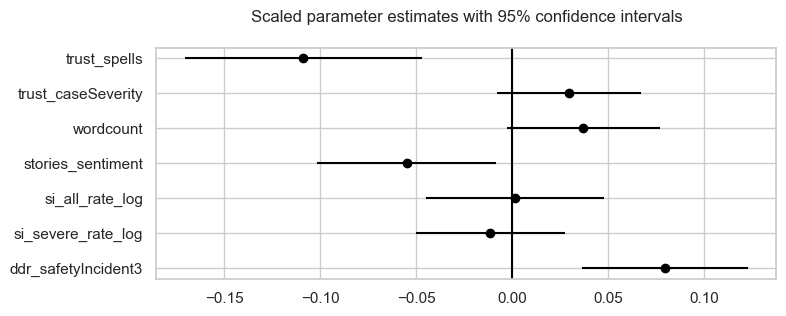

```python
coefPlot(result_custom, figsize=(8, 3));
```